# Individual differences in statistical learning

# Preparation

## R packages:

```r
library(tidyverse)
library(broom)
library(psych)
library(EFAtools)
library(lavaan)
library(ClustOfVar)
library(semTools)
library(semPlot)
library(tidySEM)
```

## Data:

```r
df = read.csv("~/GitHub/lendulet_language_SL/SEM/dataframes/filtered_SEM_df.csv")
df = df |>
  mutate(
    PROC_SPEED_vis_RT_med = -(PROC_SPEED_vis_RT_med),
    PROC_SPEED_ac_RT_med = -(PROC_SPEED_ac_RT_med),
    PROC_SPEED_vis_dec_RT_med = -(PROC_SPEED_vis_dec_RT_med),
    PROC_SPEED_ac_dec_RT_med = -(PROC_SPEED_ac_dec_RT_med),
    simon_RT_score = -(simon_RT_score),
    simon_ACC_score = -(simon_ACC_score),
    stroop_RT_score = -(stroop_RT_score),
    stroop_ACC_score = -(stroop_ACC_score),
    selfpaced_target_RT_diff_GP = -(selfpaced_target_RT_diff_GP),
    selfpaced_plus1_RT_diff_mellekmondat = -(selfpaced_plus1_RT_diff_mellekmondat),
    selfpaced_target_RT_diff_sertes = -(selfpaced_target_RT_diff_sertes)
  )
```

# 1. Selecting reliable indices

Our initial dataset comprised 12 tasks with 45 indices (Table XX). Each index has a minimum overlap of 100 with another index. For each index, two criteria were considered: (i) **unidimensionality** and (ii) **internal consistency**, indicative of its reliability. Indices failing to meet either criterion were dropped. Indices that couldn’t be evaluated were retained under the assumption that they might contain valuable information for the overall model.

Unidimensionality was assessed using Exploratory Factor Analysis (EFA) on individual items within the task index. Internal consistency was evaluated using the split-half method or omega coefficient where applicable, with a minimum reliability level set at 0.5 as the inclusion criterion.

The *trog_gramm* index was excluded due to ceiling effects. For *grammatical sensitivity* and *pragmatic comprehension* indices, the item composition was modified to meet the criteria. Since these two indices consist of qualitatively different items, to prevent overfitting, we divided the sample into two halves. One half was used to select well-fitting items in the modified index, and the other half was employed to evaluate the new structure.

Consequently, 13 indices were dropped, leaving 32 indices introduced to the EFA models.

# 2. Latent variable identification

## 2.1. Summary for the process of latent variable identification

(See details below)

To identify latent variables, we initially categorized the measurement indices into three designated domains: the *statistical learning* (SL) domain, the *general cognitive* (COG) domain, and the *language* (LANG) domain (Table XX).

In the next step, exploratory factor analyses (EFAs) were conducted within each domain, following these procedures:

1. **KMO test**: Using the Kaiser-Meyer-Olkin test, we assessed the measures of sampling adequacy (MSA) for the indices. Subsequently, indices with unsatisfactory fit for EFA (MSA < 0.6) were excluded.
2. **Bartlett’s test**: Secondly, Bartlett’s test of sphericity was employed, with the significance level indicating a suitable fit for EFA.
3. **Parallel analysis**: To determine the number of factors in each domain, Horn’s parallel analysis was used. This method compares eigenvalues derived from the data matrix to those from a Monte Carlo simulated matrix generated from random data of the same size.
4. **Exploratory factor analysis**: After determining the number of factors, exploratory factor analysis was conducted using maximum likelihood as the factoring method and promax (oblique) rotation. Missing values were imputed using the mean. Based on factor loadings and uniqueness observed in each index, we refined our model.
5. **Hierarchical cluster analysis**: To validate EFA results, hierarchical cluster analyses were performed. The stability of partitions from a hierarchy of variables was evaluated using a bootstrapping method (n=100). Based on the mean adjusted Rand criterion, we examined local maximums regarding the potential number of clusters and selected the one supported by our theoretical considerations if necessary. We then proceeded with k-means clustering of variables, resulting in the identification of latent variables.
6. **Confirmatory factor analysis**: In the final step, we validated the structure through confirmatory factor analysis. Analyses were conducted using the Robust Maximum Likelihood method, with missing values imputed by the Maximum Likelihood method. Final models were refined if necessary.

During these steps, seven indices were removed from the initial 32 indices for not meeting the KMO test criterion, and two additional indices were dropped due to model refinement. Thus, the final dataset included 23 indices from 12 different tasks (Table XXY).

## 2.2. Latent variables in statistical learning domain

**Kaiser-Meyer-Olkin test**:

```r
df %>%
  select(
    SEGM_AL_medRT_train,
    SEGM_AL_medRT_TRN3_RND4,
    SEGM_AL_medRT_RND4_REC5,
    SEGM_AL_ACC_train,
    SEGM_AL_ACC_TRN3_RND4,
    SEGM_AL_ACC_RND4_REC5,
    AGL_ACC_train,
    SEGM_AL_2AFC_bigram,
    SEGM_AL_2AFC_trigram,
    SEGM_AL_SEGM_prod_data,
    AGL_2AFC_phr,
    AGL_2AFC_sent,
    AGL_prod
  ) %>%
KMO()
```

```
ℹ 'x' was not a correlation matrix. Correlations are found from entered raw data.
```

```
── Kaiser-Meyer-Olkin criterion (KMO) ──────────────────────────────────────────────────────────────────────────────────────────────────────────────────

✖ The overall KMO value for your data is miserable.
  These data are hardly suitable for factor analysis.

  Overall: 0.551

  For each variable:
    SEGM_AL_medRT_train SEGM_AL_medRT_TRN3_RND4 SEGM_AL_medRT_RND4_REC5       SEGM_AL_ACC_train   SEGM_AL_ACC_TRN3_RND4   SEGM_AL_ACC_RND4_REC5
                  0.555                   0.530                   0.596                   0.381                   0.453                   0.388
          AGL_ACC_train     SEGM_AL_2AFC_bigram    SEGM_AL_2AFC_trigram  SEGM_AL_SEGM_prod_data            AGL_2AFC_phr           AGL_2AFC_sent
                  0.419                   0.585                   0.708                   0.756                   0.604                   0.655
               AGL_prod
                  0.645
```

Indices with unsatisfactory fit for EFA (MSA < 0.5) were excluded: * SEGM_AL_ACC_train * SEGM_AL_ACC_TRN3_RND4 * SEGM_AL_ACC_RND4_REC5 * AGL_ACC_train Then, KMO test was repeated.

```r
df %>%
  select(
    SEGM_AL_medRT_train,
    SEGM_AL_medRT_TRN3_RND4,
    SEGM_AL_medRT_RND4_REC5,
    SEGM_AL_2AFC_bigram,
    SEGM_AL_2AFC_trigram,
    SEGM_AL_SEGM_prod_data,
    AGL_2AFC_phr,
    AGL_2AFC_sent,
    AGL_prod
  ) %>%
KMO()
```

```
ℹ 'x' was not a correlation matrix. Correlations are found from entered raw data.
```

```
── Kaiser-Meyer-Olkin criterion (KMO) ──────────────────────────────────────────────────────────────────────────────────────────────────────────────────

! The overall KMO value for your data is mediocre.
  These data are probably suitable for factor analysis.

  Overall: 0.615

  For each variable:
    SEGM_AL_medRT_train SEGM_AL_medRT_TRN3_RND4 SEGM_AL_medRT_RND4_REC5     SEGM_AL_2AFC_bigram    SEGM_AL_2AFC_trigram  SEGM_AL_SEGM_prod_data
                  0.581                   0.545                   0.603                   0.595                   0.705                   0.831
           AGL_2AFC_phr           AGL_2AFC_sent                AGL_prod
                  0.604                   0.703                   0.642
```

The reaction time based indices showed poor fit (< 0.6), however, we did not omit them for their possible exploratory power. Instead, we performed two separate analysis with only the reaction time based variables and the remaining ones.

### 2.2.1. RT variables

**Bartlett’s test**:

```r
df %>%
  select(
    SEGM_AL_medRT_train,
    SEGM_AL_medRT_TRN3_RND4,
    SEGM_AL_medRT_RND4_REC5,
  ) %>%
BARTLETT()
```

```
ℹ 'x' was not a correlation matrix. Correlations are found from entered raw data.
```

```
✔ The Bartlett's test of sphericity was significant at an alpha level of .05.
  These data are probably suitable for factor analysis.

  𝜒²(3) = 799.62, p < .001
```

**Parallel analysis**:

```
Parallel analysis suggests that the number of factors =  2  and the number of components =  NA
```

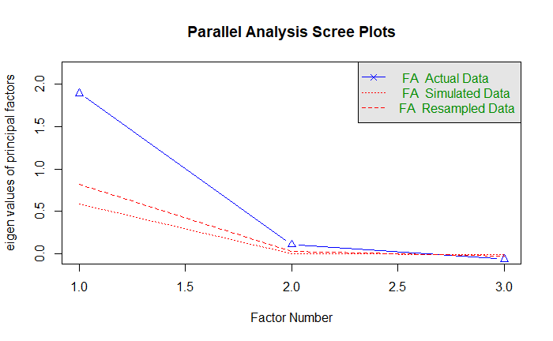

```r
df %>%
  select(
    SEGM_AL_medRT_train,
    SEGM_AL_medRT_TRN3_RND4,
    SEGM_AL_medRT_RND4_REC5,
  ) %>%
    fa.parallel(fm = "ml", fa = "fa")
```

**Exploratory factor analysis**:

```r
SL_RT = df %>%
  select(
    SEGM_AL_medRT_train,
    SEGM_AL_medRT_TRN3_RND4,
    SEGM_AL_medRT_RND4_REC5,
  ) %>%
  # maximum likelihood
  fa(
    nfactors = 1,
    fm = "ml",
    rotate = "Promax",
    use = "pairwise",
    cor = "cor",
    scores = "regression",
    missing = TRUE,
    impute = "mean"
    )
```

```r
summary(SL_RT)
```

```
Factor analysis with Call: fa(r = ., nfactors = 1, rotate = "Promax", scores = "regression",
    missing = TRUE, impute = "mean", fm = "ml", use = "pairwise",
    cor = "cor")

Test of the hypothesis that 1 factor is sufficient.
The degrees of freedom for the model is 0  and the objective function was  0.05
The number of observations was  608  with Chi Square =  28.44  with prob <  NA

The root mean square of the residuals (RMSA) is  0.06
The df corrected root mean square of the residuals is  NA

Tucker Lewis Index of factoring reliability =  -Inf
```

```r
SL_RT$loadings
```

```
Loadings:
                        ML1
SEGM_AL_medRT_train     0.690
SEGM_AL_medRT_TRN3_RND4 0.998
SEGM_AL_medRT_RND4_REC5 0.685

                 ML1
SS loadings    1.941
Proportion Var 0.647
```

```r
tidy(SL_RT$uniquenesses)
```

| names | x |
| --- | --- |
| SEGM_AL_medRT_train | 0.523464054 |
| SEGM_AL_medRT_TRN3_RND4 | 0.004990382 |
| SEGM_AL_medRT_RND4_REC5 | 0.530461398 |

### 2.2.2. Offline SL indices (non-RT indices)

**Bartlett’s test**:

```r
df %>%
  select(
    SEGM_AL_2AFC_bigram,
    SEGM_AL_2AFC_trigram,
    SEGM_AL_SEGM_prod_data,
    AGL_2AFC_phr,
    AGL_2AFC_sent,
    AGL_prod
  ) %>%
BARTLETT()
```

```
ℹ 'x' was not a correlation matrix. Correlations are found from entered raw data.
```

```
✔ The Bartlett's test of sphericity was significant at an alpha level of .05.
  These data are probably suitable for factor analysis.

  𝜒²(15) = 356.5, p < .001
```

**Parallel analysis**:

```
Parallel analysis suggests that the number of factors =  2  and the number of components =  NA
```

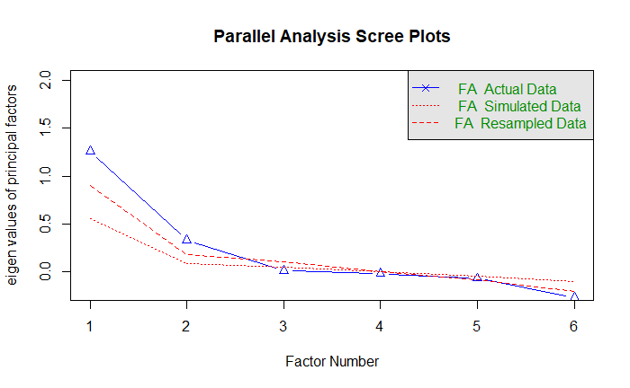

```r
df %>%
  select(
    SEGM_AL_2AFC_bigram,
    SEGM_AL_2AFC_trigram,
    SEGM_AL_SEGM_prod_data,
    AGL_2AFC_phr,
    AGL_2AFC_sent,
    AGL_prod
  ) %>%
    fa.parallel(fm = "ml", fa = "fa")
```

Parallel analysis indicates 2 factors.

**Exploratory factor analysis**:

```r
SL_OFF = df %>%
  select(
    SEGM_AL_2AFC_bigram,
    SEGM_AL_2AFC_trigram,
    SEGM_AL_SEGM_prod_data,
    AGL_2AFC_phr,
    AGL_2AFC_sent,
    AGL_prod
  ) %>%
  # maximum likelihood
  fa(
    nfactors = 2,
    fm = "ml",
    rotate = "Promax",
    use = "pairwise",
    cor = "cor",
    scores = "regression",
    missing = TRUE,
    impute = "mean"
    )
```

```r
summary(SL_OFF)
```

```
Factor analysis with Call: fa(r = ., nfactors = 2, rotate = "Promax", scores = "regression",
    missing = TRUE, impute = "mean", fm = "ml", use = "pairwise",
    cor = "cor")

Test of the hypothesis that 2 factors are sufficient.
The degrees of freedom for the model is 4  and the objective function was  0.02
The number of observations was  608  with Chi Square =  9.05  with prob <  0.06

The root mean square of the residuals (RMSA) is  0.02
The df corrected root mean square of the residuals is  0.05

Tucker Lewis Index of factoring reliability =  0.944
RMSEA index =  0.046  and the 10 % confidence intervals are  0 0.086
BIC =  -16.59
 With factor correlations of
     ML1  ML2
ML1 1.00 0.39
ML2 0.39 1.00
```

```r
SL_OFF$loadings
```

```
Loadings:
                       ML1    ML2
SEGM_AL_2AFC_bigram     0.316
SEGM_AL_2AFC_trigram    1.020
SEGM_AL_SEGM_prod_data  0.150  0.336
AGL_2AFC_phr                   0.442
AGL_2AFC_sent                  0.700
AGL_prod                       0.562

                 ML1   ML2
SS loadings    1.173 1.122
Proportion Var 0.196 0.187
Cumulative Var 0.196 0.382
```

```r
tidy(SL_OFF$uniquenesses)
```

| names | x |
| --- | --- |
| SEGM_AL_2AFC_bigram | 0.880997809 |
| SEGM_AL_2AFC_trigram | 0.004999984 |
| SEGM_AL_SEGM_prod_data | 0.824838497 |
| AGL_2AFC_phr | 0.825572052 |
| AGL_2AFC_sent | 0.542866463 |
| AGL_prod | 0.678634295 |

### 2.2.3. Final model for statistical learning variables

Since the 2-factor model showed a complex structure, we proceeded with hierarchical cluster analysis to reveal potential single-variable factors.

**Hierarchical cluster analysis**:

```r
tree_01 = df %>%
  select(
    SEGM_AL_medRT_train,
    SEGM_AL_medRT_TRN3_RND4,
    SEGM_AL_medRT_RND4_REC5,
    SEGM_AL_2AFC_bigram,
    SEGM_AL_2AFC_trigram,
    SEGM_AL_SEGM_prod_data,
    AGL_2AFC_phr,
    AGL_2AFC_sent,
    AGL_prod
  ) %>%
hclustvar()
```

[figure not shown]

```r
plot(tree_01)
```

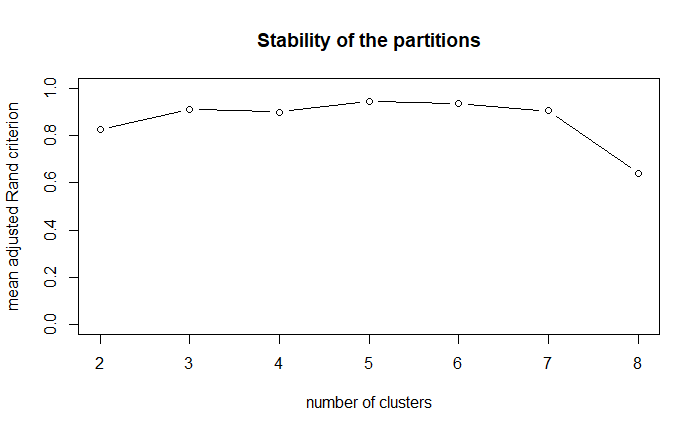

```r
stab = stability(tree_01, B=100)
```

Since the Rand criterion shows that there is two local maxima (at 3 and 5) regarding the number of clusters, we selected the greater number to get a more detailed analysis.

**K-means cluster analysis**:

```r
km = df %>%
  select(
    SEGM_AL_medRT_train,
    SEGM_AL_medRT_TRN3_RND4,
    SEGM_AL_medRT_RND4_REC5,
    SEGM_AL_2AFC_bigram,
    SEGM_AL_2AFC_trigram,
    SEGM_AL_SEGM_prod_data,
    AGL_2AFC_phr,
    AGL_2AFC_sent,
    AGL_prod
  ) %>%
kmeansvar(init = 5, nstart = 1000)
```

```r
summary(km)
```

```
Call:
kmeansvar(X.quanti = ., init = 5, nstart = 1000)

number of iterations:  1

Data:
   number of observations:  608
   number of variables:  9
   number of clusters:  5

Cluster  1 :
                        squared loading correlation
SEGM_AL_medRT_TRN3_RND4            0.89       -0.94
SEGM_AL_medRT_train                0.64       -0.80
SEGM_AL_medRT_RND4_REC5            0.64       -0.80


Cluster  2 :
                     squared loading correlation
SEGM_AL_2AFC_bigram             0.67       -0.82
SEGM_AL_2AFC_trigram            0.67       -0.82


Cluster  3 :
squared loading     correlation
              1               1


Cluster  4 :
squared loading     correlation
              1               1


Cluster  5 :
              squared loading correlation
AGL_2AFC_sent            0.69       -0.83
AGL_prod                 0.69       -0.83


Gain in cohesion (in %):  67.34
```

In conclusion, we used these 5 clusters of statistical learning variables to identify latent variables which later serve as predictors in the SEM models. We tested the robustness of the results with confirmatory factor analysis.

**Confirmatory factor analysis**:

```r
model_SL =
"
  SL_RT =~ SEGM_AL_medRT_train + SEGM_AL_medRT_TRN3_RND4 + SEGM_AL_medRT_RND4_REC5
  SL_tribi =~ SEGM_AL_2AFC_bigram + SEGM_AL_2AFC_trigram
  SL_SEGM_prod =~ SEGM_AL_SEGM_prod_data
  SL_AGL =~ AGL_2AFC_sent + AGL_prod
  SL_phr =~ AGL_2AFC_phr
"
```

**Model fits for CFA**:

```r
model_SL_fit = cfa(model_SL, df, missing = "ML", estimator = "MLR")
summary(model_SL_fit, standardized = TRUE, fit.measures = TRUE)
```

```
lavaan 0.6.16 ended normally after 51 iterations

  Estimator                                         ML
  Optimization method                           NLMINB
  Number of model parameters                        35

                                                  Used       Total
  Number of observations                           386         608
  Number of missing patterns                        11

Model Test User Model:
                                              Standard      Scaled
  Test Statistic                                29.141      30.182
  Degrees of freedom                                19          19
  P-value (Chi-square)                           0.064       0.050
  Scaling correction factor                                  0.966
    Yuan-Bentler correction (Mplus variant)

Model Test Baseline Model:

  Test statistic                               559.241     481.464
  Degrees of freedom                                36          36
  P-value                                        0.000       0.000
  Scaling correction factor                                  1.162

User Model versus Baseline Model:

  Comparative Fit Index (CFI)                    0.981       0.975
  Tucker-Lewis Index (TLI)                       0.963       0.952

  Robust Comparative Fit Index (CFI)                         0.983
  Robust Tucker-Lewis Index (TLI)                            0.967

Loglikelihood and Information Criteria:

  Loglikelihood user model (H0)              -3119.162   -3119.162
  Scaling correction factor                                  1.218
      for the MLR correction
  Loglikelihood unrestricted model (H1)      -3104.591   -3104.591
  Scaling correction factor                                  1.129
```

[output cut: 82 more lines]

```
                   Estimate  Std.Err  z-value  P(>|z|)   Std.lv  Std.all
   .SEGM_AL_mdRT_t    0.406    0.072    5.595    0.000    0.406    0.598
   .SEGM_AL_RT_TRN   -0.165    0.101   -1.629    0.103   -0.165   -0.194
   .SEGM_AL_RT_RND    0.532    0.100    5.344    0.000    0.532    0.608
   .SEGM_AL_2AFC_b    0.857    0.091    9.387    0.000    0.857    0.850
   .SEGM_AL_2AFC_t    0.264    0.290    0.911    0.362    0.264    0.251
   .SEGM_AL_SEGM__    0.000                               0.000    0.000
   .AGL_2AFC_sent     0.585    0.105    5.568    0.000    0.585    0.600
   .AGL_prod          0.603    0.106    5.713    0.000    0.603    0.623
   .AGL_2AFC_phr      0.000                               0.000    0.000
    SL_RT             0.273    0.058    4.740    0.000    1.000    1.000
    SL_tribi          0.152    0.074    2.059    0.040    1.000    1.000
    SL_SEGM_prod      0.920    0.064   14.389    0.000    1.000    1.000
    SL_AGL            0.390    0.112    3.492    0.000    1.000    1.000
    SL_phr            0.966    0.080   12.034    0.000    1.000    1.000
```

In one case (*SEGM_AL_2AFC_bigram*), the unexplained variance was high (>0.65), however we kept it to assign convergent reliability to the SL_trigram variable. We further excluded the *SEGM_AL_midRT_train* variable to solve the Heywood case present in this factor.

The final grouping of the variables is:

1. **SEGM_RT**:
- SEGM_AL_medRT_TRN3_RND4
- SEGM_AL_medRT_RND4_REC5
2. **SEGM_2_AFC**:
- SEGM_AL_2AFC_trigram
- SEGM_AL_2AFC_bigram (for reliability purpose)
3. **SL_SEGM_production**:
- SEGM_AL_SEGM_prod_data
4. **SL_AGL**:
- AGL_2AFC_sent
- AGL_prod
5. **AGL_phrase**:
- AGL_2AFC_phr

## 2.3. Latent variables in general cognitive domain

**Kaiser-Meyer-Olkin test**:

```r
df %>%
  select(
    PROC_SPEED_vis_RT_med,
    PROC_SPEED_ac_RT_med,
    PROC_SPEED_vis_dec_RT_med,
    digit_span_forward_span,
    digit_span_backward_span,
    n_back_nback_1_dprime,
    n_back_nback_2_dprime,
    n_back_nback_3_dprime,
    stroop_RT_score,
    stroop_ACC_score,
    simon_RT_score,
    simon_ACC_score
  ) %>%
KMO()
```

```
ℹ 'x' was not a correlation matrix. Correlations are found from entered raw data.
```

```
── Kaiser-Meyer-Olkin criterion (KMO) ──────────────────────────────────────────────────────────────────────────────────────────────────────────────────

! The overall KMO value for your data is mediocre.
  These data are probably suitable for factor analysis.

  Overall: 0.699

  For each variable:
    PROC_SPEED_vis_RT_med      PROC_SPEED_ac_RT_med PROC_SPEED_vis_dec_RT_med   digit_span_forward_span  digit_span_backward_span
                    0.728                     0.712                     0.811                     0.654                     0.628
    n_back_nback_1_dprime     n_back_nback_2_dprime     n_back_nback_3_dprime           stroop_RT_score          stroop_ACC_score
                    0.766                     0.650                     0.672                     0.677                     0.594
           simon_RT_score           simon_ACC_score
                    0.787                     0.455
```

Indices with unsatisfactory fit for EFA (MSA < 0.6) were excluded: * simon_ACC_score * stroop_ACC_score Then, KMO test was repeated.

```r
df %>%
  select(
    PROC_SPEED_vis_RT_med,
    PROC_SPEED_ac_RT_med,
    PROC_SPEED_vis_dec_RT_med,
    digit_span_forward_span,
    digit_span_backward_span,
    n_back_nback_1_dprime,
    n_back_nback_2_dprime,
    n_back_nback_3_dprime,
    stroop_RT_score,
    simon_RT_score,
  ) %>%
KMO()
```

```
ℹ 'x' was not a correlation matrix. Correlations are found from entered raw data.
```

```
── Kaiser-Meyer-Olkin criterion (KMO) ──────────────────────────────────────────────────────────────────────────────────────────────────────────────────

✔ The overall KMO value for your data is middling.
  These data are probably suitable for factor analysis.

  Overall: 0.716

  For each variable:
    PROC_SPEED_vis_RT_med      PROC_SPEED_ac_RT_med PROC_SPEED_vis_dec_RT_med   digit_span_forward_span  digit_span_backward_span
                    0.741                     0.709                     0.803                     0.651                     0.631
    n_back_nback_1_dprime     n_back_nback_2_dprime     n_back_nback_3_dprime           stroop_RT_score            simon_RT_score
                    0.776                     0.652                     0.674                     0.732                     0.828
```

**Bartlett’s test**:

```r
df %>%
  select(
    PROC_SPEED_vis_RT_med,
    PROC_SPEED_ac_RT_med,
    PROC_SPEED_vis_dec_RT_med,
    digit_span_forward_span,
    digit_span_backward_span,
    n_back_nback_1_dprime,
    n_back_nback_2_dprime,
    n_back_nback_3_dprime,
    stroop_RT_score,
    simon_RT_score,
  ) %>%
BARTLETT()
```

```
ℹ 'x' was not a correlation matrix. Correlations are found from entered raw data.
```

```
✔ The Bartlett's test of sphericity was significant at an alpha level of .05.
  These data are probably suitable for factor analysis.

  𝜒²(45) = 1383.5, p < .001
```

**Parallel analysis**:

```
Parallel analysis suggests that the number of factors =  4  and the number of components =  NA
```

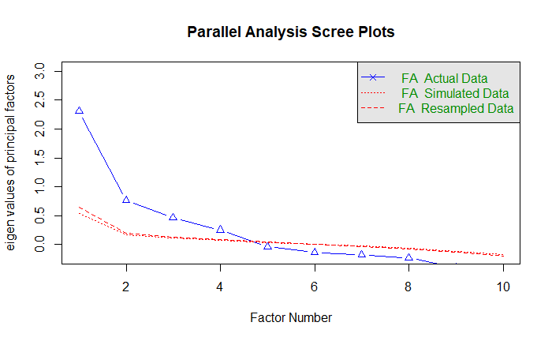

```r
df %>%
  select(
    PROC_SPEED_vis_RT_med,
    PROC_SPEED_ac_RT_med,
    PROC_SPEED_vis_dec_RT_med,
    digit_span_forward_span,
    digit_span_backward_span,
    n_back_nback_1_dprime,
    n_back_nback_2_dprime,
    n_back_nback_3_dprime,
    stroop_RT_score,
    simon_RT_score,
  ) %>%
    fa.parallel(fm = "ml", fa = "fa")
```

**Exploratory factor analysis**:

```r
COG_EFA = df %>%
  select(
    PROC_SPEED_vis_RT_med,
    PROC_SPEED_ac_RT_med,
    PROC_SPEED_vis_dec_RT_med,
    digit_span_forward_span,
    digit_span_backward_span,
    n_back_nback_1_dprime,
    n_back_nback_2_dprime,
    n_back_nback_3_dprime,
    stroop_RT_score,
    simon_RT_score,
  ) %>%
  # maximum likelihood
  fa(
    nfactors = 4,
    fm = "ml",
    rotate = "Promax",
    use = "pairwise",
    cor = "cor",
    scores = "regression",
    missing = TRUE,
    impute = "mean"
    )
```

```r
summary(COG_EFA)
```

```
Factor analysis with Call: fa(r = ., nfactors = 4, rotate = "Promax", scores = "regression",
    missing = TRUE, impute = "mean", fm = "ml", use = "pairwise",
    cor = "cor")

Test of the hypothesis that 4 factors are sufficient.
The degrees of freedom for the model is 11  and the objective function was  0.04
The number of observations was  608  with Chi Square =  22.31  with prob <  0.022

The root mean square of the residuals (RMSA) is  0.01
The df corrected root mean square of the residuals is  0.03

Tucker Lewis Index of factoring reliability =  0.965
RMSEA index =  0.041  and the 10 % confidence intervals are  0.015 0.066
BIC =  -48.21
 With factor correlations of
     ML2  ML3  ML1  ML4
ML2 1.00 0.34 0.17 0.36
ML3 0.34 1.00 0.34 0.50
ML1 0.17 0.34 1.00 0.38
ML4 0.36 0.50 0.38 1.00
```

```r
COG_EFA$loadings
```

```
Loadings:
                          ML2    ML3    ML1    ML4
PROC_SPEED_vis_RT_med             0.780
PROC_SPEED_ac_RT_med              0.714        -0.148
PROC_SPEED_vis_dec_RT_med         0.497         0.310
digit_span_forward_span           0.155  0.532
digit_span_backward_span                 1.012
n_back_nback_1_dprime      0.524                0.153
n_back_nback_2_dprime      0.880
n_back_nback_3_dprime      0.674               -0.120
stroop_RT_score                  -0.111         0.649
simon_RT_score                    0.140         0.518

                 ML2   ML3   ML1   ML4
SS loadings    1.516 1.434 1.318 0.848
Proportion Var 0.152 0.143 0.132 0.085
Cumulative Var 0.152 0.295 0.427 0.512
```

```r
tidy(COG_EFA$uniquenesses)
```

| names | x |
| --- | --- |
| PROC_SPEED_vis_RT_med | 0.363821615 |
| PROC_SPEED_ac_RT_med | 0.606249483 |
| PROC_SPEED_vis_dec_RT_med | 0.516627798 |
| digit_span_forward_span | 0.626645926 |
| digit_span_backward_span | 0.004999742 |
| n_back_nback_1_dprime | 0.662312982 |
| n_back_nback_2_dprime | 0.272344292 |
| n_back_nback_3_dprime | 0.555526373 |
| stroop_RT_score | 0.649908369 |
| simon_RT_score | 0.634048624 |

For further analysis, we performed hierarchical variable clustering on the general cognitive variables as well.

**Hierarchical cluster analysis**:

```r
tree_01 = df %>%
  select(
    PROC_SPEED_vis_RT_med,
    PROC_SPEED_ac_RT_med,
    PROC_SPEED_vis_dec_RT_med,
    digit_span_forward_span,
    digit_span_backward_span,
    n_back_nback_1_dprime,
    n_back_nback_2_dprime,
    n_back_nback_3_dprime,
    stroop_RT_score,
    simon_RT_score,
  ) %>%
hclustvar()
```

[figure not shown]

```r
plot(tree_01)
```

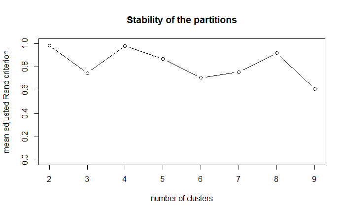

```r
stab = stability(tree_01, B=100)
```

**K-means cluster analysis**:

```r
km = df %>%
  select(
    PROC_SPEED_vis_RT_med,
    PROC_SPEED_ac_RT_med,
    PROC_SPEED_vis_dec_RT_med,
    digit_span_forward_span,
    digit_span_backward_span,
    n_back_nback_1_dprime,
    n_back_nback_2_dprime,
    n_back_nback_3_dprime,
    stroop_RT_score,
    simon_RT_score,
  ) %>%
kmeansvar(init = 4, nstart = 1000)
```

```r
summary(km)
```

```
Call:
kmeansvar(X.quanti = ., init = 4, nstart = 1000)

number of iterations:  1

Data:
   number of observations:  608
   number of variables:  10
   number of clusters:  4

Cluster  1 :
                          squared loading correlation
PROC_SPEED_vis_RT_med                0.71       -0.85
PROC_SPEED_vis_dec_RT_med            0.56       -0.78
PROC_SPEED_ac_RT_med                 0.56       -0.75


Cluster  2 :
                         squared loading correlation
digit_span_backward_span            0.79       -0.89
digit_span_forward_span             0.79       -0.89


Cluster  3 :
                      squared loading correlation
n_back_nback_2_dprime            0.75       -0.86
n_back_nback_3_dprime            0.63       -0.80
n_back_nback_1_dprime            0.55       -0.74


Cluster  4 :
                squared loading correlation
simon_RT_score             0.66        0.81
stroop_RT_score            0.66        0.81


Gain in cohesion (in %):  53.79
```

In conclusion, we have 4 clusters of cognitive variables:

1. **Processing Speed**:
- PROC_SPEED_vis_RT_med,
- PROC_SPEED_ac_RT_med,
- PROC_SPEED_vis_dec_RT_med
2. **Digit Span**:
- digit_span_forward_span,
- digit_span_backward_span
3. **NBACK test**:
- n_back_nback_1_dprime,
- n_back_nback_2_dprime,
- n_back_nback_3_dprime
4. **Reaction Time**:
- stroop_RT_score,
- simon_RT_score

As the following step, we tested whether these factors shows an appropriate fit using cfa.

**Confirmatory factor analysis**:

```r
model_COG =
"
  COG_PS =~ PROC_SPEED_vis_RT_med + PROC_SPEED_vis_dec_RT_med + PROC_SPEED_ac_RT_med
  COG_DS =~ digit_span_forward_span + digit_span_backward_span
  COG_nback =~ n_back_nback_1_dprime + n_back_nback_2_dprime + n_back_nback_3_dprime
  COG_RT =~ stroop_RT_score + simon_RT_score
"
```

**Model fits for CFA**:

```r
model_COG_fit = cfa(model_COG, df, missing = "ML", estimator = "MLR")
summary(model_COG_fit, standardized = TRUE, fit.measures = TRUE)
```

```
lavaan 0.6.16 ended normally after 43 iterations

  Estimator                                         ML
  Optimization method                           NLMINB
  Number of model parameters                        36

                                                  Used       Total
  Number of observations                           588         608
  Number of missing patterns                        40

Model Test User Model:
                                              Standard      Scaled
  Test Statistic                                75.186      74.394
  Degrees of freedom                                29          29
  P-value (Chi-square)                           0.000       0.000
  Scaling correction factor                                  1.011
    Yuan-Bentler correction (Mplus variant)

Model Test Baseline Model:

  Test statistic                              1151.464    1024.285
  Degrees of freedom                                45          45
  P-value                                        0.000       0.000
  Scaling correction factor                                  1.124

User Model versus Baseline Model:

  Comparative Fit Index (CFI)                    0.958       0.954
  Tucker-Lewis Index (TLI)                       0.935       0.928

  Robust Comparative Fit Index (CFI)                         0.952
  Robust Tucker-Lewis Index (TLI)                            0.925

Loglikelihood and Information Criteria:

  Loglikelihood user model (H0)              -6235.268   -6235.268
  Scaling correction factor                                  1.956
      for the MLR correction
  Loglikelihood unrestricted model (H1)      -6197.675   -6197.675
  Scaling correction factor                                  1.534
```

[output cut: 77 more lines]

```
                   Estimate  Std.Err  z-value  P(>|z|)   Std.lv  Std.all
   .PROC_SPEED__RT    0.275    0.060    4.593    0.000    0.275    0.339
   .PROC_SPEED___R    0.470    0.076    6.173    0.000    0.470    0.443
   .PROC_SPEED__RT    0.623    0.078    7.999    0.000    0.623    0.693
   .dgt_spn_frwrd_    0.395    0.078    5.071    0.000    0.395    0.401
   .dgt_spn_bckwr_    0.440    0.076    5.821    0.000    0.440    0.435
   .n_bck_nbck_1_d    0.640    0.050   12.768    0.000    0.640    0.665
   .n_bck_nbck_2_d    0.260    0.068    3.819    0.000    0.260    0.286
   .n_bck_nbck_3_d    0.560    0.062    8.970    0.000    0.560    0.558
   .stroop_RT_scor    0.672    0.121    5.541    0.000    0.672    0.729
   .simon_RT_score    0.580    0.107    5.424    0.000    0.580    0.558
    COG_PS            0.537    0.123    4.360    0.000    1.000    1.000
    COG_DS            0.590    0.100    5.889    0.000    1.000    1.000
    COG_nback         0.323    0.063    5.117    0.000    1.000    1.000
    COG_RT            0.250    0.143    1.744    0.081    1.000    1.000
```

In three cases the unexplained variance is very high (>0.65). 1. First, we excluded the *nback_1_dprime* variable, since it does not carry more information compared to *nback_2_dprime* and *nback_3_dprime* variables both theoretically and measurement-wise. 2. Secondly, we split the *COG_RT factor* into two, since the *stroop* and *simon* tasks have potentially additional exploratory power in the model. 3. Thirdly, we split the *COG_PS factor* into two. (For detail see next section.)

To split the COG_PS into two factor, we performed two cfa analyses with nested models (*model_PS_01* and *model_PS_02*).

**First model / Model_PS_01**:

```r
model_PS_01 =
"
  PS_01 =~ PROC_SPEED_vis_RT_med + PROC_SPEED_vis_dec_RT_med
  PS_02 =~ PROC_SPEED_ac_RT_med
  COG_DS =~ digit_span_forward_span + digit_span_backward_span
  COG_nback =~ n_back_nback_2_dprime + n_back_nback_3_dprime
  COG_stroop =~ stroop_RT_score
  COG_simon =~ simon_RT_score
"
```

```r
model_PS_01_fit = cfa(model_PS_01, df, missing = "ML", estimator = "MLR")
summary(model_PS_01_fit, standardized = TRUE, fit.measures = TRUE)
```

```
lavaan 0.6.16 ended normally after 41 iterations

  Estimator                                         ML
  Optimization method                           NLMINB
  Number of model parameters                        39

                                                  Used       Total
  Number of observations                           588         608
  Number of missing patterns                        40

Model Test User Model:
                                              Standard      Scaled
  Test Statistic                                44.698      41.625
  Degrees of freedom                                15          15
  P-value (Chi-square)                           0.000       0.000
  Scaling correction factor                                  1.074
    Yuan-Bentler correction (Mplus variant)

Model Test Baseline Model:

  Test statistic                              1005.137     864.414
  Degrees of freedom                                36          36
  P-value                                        0.000       0.000
  Scaling correction factor                                  1.163

User Model versus Baseline Model:

  Comparative Fit Index (CFI)                    0.969       0.968
  Tucker-Lewis Index (TLI)                       0.926       0.923

  Robust Comparative Fit Index (CFI)                         0.965
  Robust Tucker-Lewis Index (TLI)                            0.917

Loglikelihood and Information Criteria:

  Loglikelihood user model (H0)              -5640.834   -5640.834
  Scaling correction factor                                  1.869
      for the MLR correction
  Loglikelihood unrestricted model (H1)      -5618.485   -5618.485
  Scaling correction factor                                  1.648
```

[output cut: 91 more lines]

```
   .PROC_SPEED__RT    0.298    0.044    6.706    0.000    0.298    0.366
   .PROC_SPEED___R    0.474    0.060    7.866    0.000    0.474    0.444
   .PROC_SPEED__RT    0.000                               0.000    0.000
   .dgt_spn_frwrd_    0.432    0.078    5.531    0.000    0.432    0.438
   .dgt_spn_bckwr_    0.403    0.081    4.962    0.000    0.403    0.398
   .n_bck_nbck_2_d    0.395    0.137    2.878    0.004    0.395    0.437
   .n_bck_nbck_3_d    0.429    0.151    2.832    0.005    0.429    0.426
   .stroop_RT_scor    0.000                               0.000    0.000
   .simon_RT_score    0.000                               0.000    0.000
    PS_01             0.517    0.114    4.550    0.000    1.000    1.000
    PS_02             0.890    0.101    8.788    0.000    1.000    1.000
    COG_DS            0.554    0.099    5.595    0.000    1.000    1.000
    COG_nback         0.509    0.145    3.503    0.000    1.000    1.000
    COG_stroop        0.926    0.219    4.224    0.000    1.000    1.000
    COG_simon         1.042    0.199    5.237    0.000    1.000    1.000
```

**Second model / Model_PS_02**:

```r
model_PS_02 =
"
  PS_01 =~ PROC_SPEED_vis_RT_med + PROC_SPEED_ac_RT_med
  PS_02 =~ PROC_SPEED_vis_dec_RT_med
  COG_DS =~ digit_span_forward_span + digit_span_backward_span
  COG_nback =~ n_back_nback_2_dprime + n_back_nback_3_dprime
  COG_stroop =~ stroop_RT_score
  COG_simon =~ simon_RT_score
"
```

```r
model_PS_02_fit = cfa(model_PS_02, df, missing = "ML", estimator = "MLR")
summary(model_PS_02_fit, standardized = TRUE, fit.measures = TRUE)
```

```
lavaan 0.6.16 ended normally after 41 iterations

  Estimator                                         ML
  Optimization method                           NLMINB
  Number of model parameters                        39

                                                  Used       Total
  Number of observations                           588         608
  Number of missing patterns                        40

Model Test User Model:
                                              Standard      Scaled
  Test Statistic                                22.637      21.557
  Degrees of freedom                                15          15
  P-value (Chi-square)                           0.092       0.120
  Scaling correction factor                                  1.050
    Yuan-Bentler correction (Mplus variant)

Model Test Baseline Model:

  Test statistic                              1005.137     864.414
  Degrees of freedom                                36          36
  P-value                                        0.000       0.000
  Scaling correction factor                                  1.163

User Model versus Baseline Model:

  Comparative Fit Index (CFI)                    0.992       0.992
  Tucker-Lewis Index (TLI)                       0.981       0.981

  Robust Comparative Fit Index (CFI)                         0.995
  Robust Tucker-Lewis Index (TLI)                            0.988

Loglikelihood and Information Criteria:

  Loglikelihood user model (H0)              -5629.803   -5629.803
  Scaling correction factor                                  1.878
      for the MLR correction
  Loglikelihood unrestricted model (H1)      -5618.485   -5618.485
  Scaling correction factor                                  1.648
```

[output cut: 91 more lines]

```
   .PROC_SPEED__RT    0.128    0.079    1.627    0.104    0.128    0.159
   .PROC_SPEED__RT    0.624    0.074    8.451    0.000    0.624    0.698
   .PROC_SPEED___R    0.000                               0.000    0.000
   .dgt_spn_frwrd_    0.422    0.075    5.630    0.000    0.422    0.428
   .dgt_spn_bckwr_    0.413    0.077    5.392    0.000    0.413    0.408
   .n_bck_nbck_2_d    0.398    0.119    3.337    0.001    0.398    0.441
   .n_bck_nbck_3_d    0.425    0.134    3.177    0.001    0.425    0.421
   .stroop_RT_scor    0.000                               0.000    0.000
   .simon_RT_score    0.000                               0.000    0.000
    PS_01             0.680    0.137    4.971    0.000    1.000    1.000
    PS_02             1.111    0.155    7.155    0.000    1.000    1.000
    COG_DS            0.564    0.096    5.896    0.000    1.000    1.000
    COG_nback         0.506    0.125    4.048    0.000    1.000    1.000
    COG_stroop        0.925    0.217    4.258    0.000    1.000    1.000
    COG_simon         1.037    0.197    5.263    0.000    1.000    1.000
```

Based on the two models, we concluded that *model_PS_02* indicates a better model considering four fit indices (TLI, CFI, SRMR, RMSEA) and the BIC. So for further analyses, we used the *PROC_SPEED_vis_dec_RT_med* index as a single-variable latent factor retaining the other two variables as the *PS factor*.

The final grouping of the variables is the following structure:

1. **Processing Speed**:
- PROC_SPEED_vis_RT_med,
- PROC_SPEED_ac_RT_med
2. **Visual Decision Speed**:
- PROC_SPEED_vis_dec_RT_med
3. **Digit Span**:
- digit_span_forward_span,
- digit_span_backward_span
4. **NBACK test**:
- n_back_nback_2_dprime,
- n_back_nback_3_dprime
5. **Stroop task**:
- stroop_RT_score
6. **Simon task**:
- simon_RT_score

## 2.4. Latent variables in language domain

**Kaiser-Meyer-Olkin test**:

```r
df %>%
  select(
    MENYET_mean_ACC_all,
    OMR_read_syls,
    predictive_RT_score,
    predictive_ACC_score,
    selfpaced_target_RT_diff_GP,
    selfpaced_target_RT_diff_sertes,
    trog_pragm_ACC_mean
  ) %>%
KMO()
```

```
ℹ 'x' was not a correlation matrix. Correlations are found from entered raw data.
```

```
── Kaiser-Meyer-Olkin criterion (KMO) ──────────────────────────────────────────────────────────────────────────────────────────────────────────────────

✖ The overall KMO value for your data is miserable.
  These data are hardly suitable for factor analysis.

  Overall: 0.594

  For each variable:
            MENYET_mean_ACC_all                   OMR_read_syls             predictive_RT_score            predictive_ACC_score
                          0.565                           0.673                           0.518                           0.465
    selfpaced_target_RT_diff_GP selfpaced_target_RT_diff_sertes             trog_pragm_ACC_mean
                          0.617                           0.623                           0.620
```

We excluded the *predictive_ACC_score* index which showed unacceptable KMO values (< 0.5).

```r
df %>%
  select(
    MENYET_mean_ACC_all,
    OMR_read_syls,
    predictive_RT_score,
    selfpaced_target_RT_diff_GP,
    selfpaced_target_RT_diff_sertes,
    trog_pragm_ACC_mean
  ) %>%
KMO()
```

```
ℹ 'x' was not a correlation matrix. Correlations are found from entered raw data.
```

```
── Kaiser-Meyer-Olkin criterion (KMO) ──────────────────────────────────────────────────────────────────────────────────────────────────────────────────

! The overall KMO value for your data is mediocre.
  These data are probably suitable for factor analysis.

  Overall: 0.624

  For each variable:
            MENYET_mean_ACC_all                   OMR_read_syls             predictive_RT_score     selfpaced_target_RT_diff_GP
                          0.613                           0.670                           0.594                           0.601
selfpaced_target_RT_diff_sertes             trog_pragm_ACC_mean
                          0.628                           0.631
```

All indices are now in the acceptable range (> 0.6), and the *predictive_RT_score* is also near the boundary.

**Parallel analysis**:

```
Parallel analysis suggests that the number of factors =  2  and the number of components =  NA
```

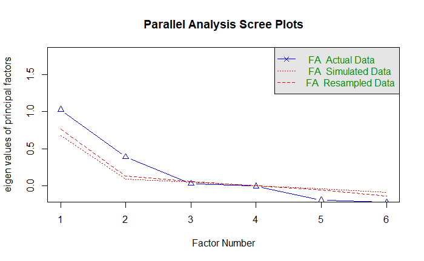

```r
df %>%
  select(
    MENYET_mean_ACC_all,
    OMR_read_syls,
    predictive_RT_score,
    selfpaced_target_RT_diff_GP,
    selfpaced_target_RT_diff_sertes,
    trog_pragm_ACC_mean
  ) %>%
    fa.parallel(fm = "ml", fa = "fa")
```

Parallel analysis indicates 2 factors emerging.

**Exploratory factor analysis**:

```r
LANG_EFA = df %>%
  select(
    MENYET_mean_ACC_all,
    OMR_read_syls,
    predictive_RT_score,
    selfpaced_target_RT_diff_GP,
    selfpaced_target_RT_diff_sertes,
    trog_pragm_ACC_mean
  ) %>%
  # maximum likelihood
  fa(
    nfactors = 2,
    fm = "ml",
    rotate = "Promax",
    use = "pairwise",
    cor = "cor",
    scores = "regression",
    missing = TRUE,
    impute = "mean"
    )
```

```r
summary(LANG_EFA)
```

```
Factor analysis with Call: fa(r = ., nfactors = 2, rotate = "Promax", scores = "regression",
    missing = TRUE, impute = "mean", fm = "ml", use = "pairwise",
    cor = "cor")

Test of the hypothesis that 2 factors are sufficient.
The degrees of freedom for the model is 4  and the objective function was  0.02
The number of observations was  608  with Chi Square =  12.06  with prob <  0.017

The root mean square of the residuals (RMSA) is  0.03
The df corrected root mean square of the residuals is  0.05

Tucker Lewis Index of factoring reliability =  0.881
RMSEA index =  0.058  and the 10 % confidence intervals are  0.022 0.096
BIC =  -13.58
 With factor correlations of
     ML1  ML2
ML1 1.00 0.32
ML2 0.32 1.00
```

```r
LANG_EFA$loadings
```

```
Loadings:
                                ML1    ML2
MENYET_mean_ACC_all                     0.539
OMR_read_syls                    0.456
predictive_RT_score                     0.410
selfpaced_target_RT_diff_GP      0.620
selfpaced_target_RT_diff_sertes  0.594
trog_pragm_ACC_mean                     0.471

                 ML1   ML2
SS loadings    0.947 0.693
Proportion Var 0.158 0.115
Cumulative Var 0.158 0.273
```

```r
tidy(LANG_EFA$uniquenesses)
```

| names | x |
| --- | --- |
| MENYET_mean_ACC_all | 0.7203412 |
| OMR_read_syls | 0.7628915 |
| predictive_RT_score | 0.8354890 |
| selfpaced_target_RT_diff_GP | 0.6389566 |
| selfpaced_target_RT_diff_sertes | 0.6423169 |
| trog_pragm_ACC_mean | 0.7753736 |

Since the 2-factor model showed a complex structure, we proceeded with hierarchical cluster analysis to reveal potential single-variable factors.

**Hierarchical cluster analysis**:

```r
tree_01 = df %>%
  select(
    MENYET_mean_ACC_all,
    OMR_read_syls,
    predictive_RT_score,
    selfpaced_target_RT_diff_GP,
    selfpaced_target_RT_diff_sertes,
    trog_pragm_ACC_mean
  ) %>%
hclustvar()
```

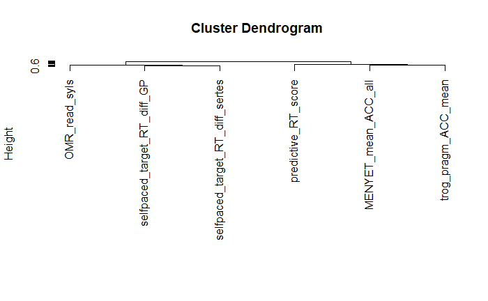

```r
plot(tree_01)
```

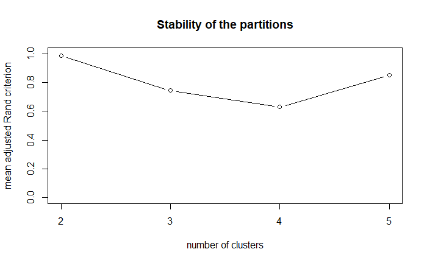

```r
stab = stability(tree_01, B=100)
```

**K-means cluster analysis**:

```r
km = df %>%
  select(
    MENYET_mean_ACC_all,
    OMR_read_syls,
    predictive_RT_score,
    selfpaced_target_RT_diff_GP,
    selfpaced_target_RT_diff_sertes,
    trog_pragm_ACC_mean

  ) %>%
kmeansvar(init = 5, nstart = 1000)
```

```r
summary(km)
```

```
Call:
kmeansvar(X.quanti = ., init = 5, nstart = 1000)

number of iterations:  1

Data:
   number of observations:  608
   number of variables:  6
   number of clusters:  5

Cluster  1 :
squared loading     correlation
              1               1


Cluster  2 :
squared loading     correlation
              1               1


Cluster  3 :
squared loading     correlation
              1               1


Cluster  4 :
                                squared loading correlation
selfpaced_target_RT_diff_GP                0.68       -0.82
selfpaced_target_RT_diff_sertes            0.68       -0.82


Cluster  5 :
squared loading     correlation
              1               1


Gain in cohesion (in %):  85.03
```

As a next step, we tested whether these factors show appropriate fit using cfa.

**Confirmatory factor analysis**:

```r
model_LANG =
"
  LANG_MENYET =~ MENYET_mean_ACC_all
  LANG_OMR =~ OMR_read_syls
  LANG_pred =~ predictive_RT_score
  LANG_space =~ selfpaced_target_RT_diff_GP + selfpaced_target_RT_diff_sertes
  LANG_TROG =~ trog_pragm_ACC_mean
"
```

**Fit indices for CFA**:

```r
model_LANG_fit = cfa(model_LANG, df, missing = "ML", estimator = "MLR")
summary(model_LANG_fit, standardized = TRUE, fit.measures = TRUE)
```

```
lavaan 0.6.16 ended normally after 25 iterations

  Estimator                                         ML
  Optimization method                           NLMINB
  Number of model parameters                        24

                                                  Used       Total
  Number of observations                           530         608
  Number of missing patterns                        21

Model Test User Model:
                                              Standard      Scaled
  Test Statistic                                 4.842       5.669
  Degrees of freedom                                 3           3
  P-value (Chi-square)                           0.184       0.129
  Scaling correction factor                                  0.854
    Yuan-Bentler correction (Mplus variant)

Model Test Baseline Model:

  Test statistic                               182.193     152.145
  Degrees of freedom                                15          15
  P-value                                        0.000       0.000
  Scaling correction factor                                  1.197

User Model versus Baseline Model:

  Comparative Fit Index (CFI)                    0.989       0.981
  Tucker-Lewis Index (TLI)                       0.945       0.903

  Robust Comparative Fit Index (CFI)                         0.989
  Robust Tucker-Lewis Index (TLI)                            0.944

Loglikelihood and Information Criteria:

  Loglikelihood user model (H0)              -3578.118   -3578.118
  Scaling correction factor                                  1.470
      for the MLR correction
  Loglikelihood unrestricted model (H1)      -3575.697   -3575.697
  Scaling correction factor                                  1.401
```

[output cut: 73 more lines]

```
    LANG_TROG         0.000                               0.000    0.000

Variances:
                   Estimate  Std.Err  z-value  P(>|z|)   Std.lv  Std.all
   .MENYET_mn_ACC_    0.000                               0.000    0.000
   .OMR_read_syls     0.000                               0.000    0.000
   .predctv_RT_scr    0.000                               0.000    0.000
   .slfpcd__RT__GP    0.678    0.121    5.621    0.000    0.678    0.660
   .slfpcd_tr_RT__    0.454    0.109    4.175    0.000    0.454    0.614
   .trg_prgm_ACC_m    0.000                               0.000    0.000
    LANG_MENYET       0.987    0.081   12.189    0.000    1.000    1.000
    LANG_OMR          0.984    0.087   11.370    0.000    1.000    1.000
    LANG_pred         1.020    0.042   24.152    0.000    1.000    1.000
    LANG_space        0.350    0.138    2.536    0.011    1.000    1.000
    LANG_TROG         0.974    0.073   13.302    0.000    1.000    1.000
```

In conclusion, we used 5 clusters of language related variables to identify latent variables which serve as outcome in the SEM models.

The final structure is:

1. **grammatical sensitivity**
- MENYET_mean_ACC_all
2. **one minute reading**
- OMR_read_syls
3. **predictive sentence processing**
- predictive_RT_score
4. **self-paced reading**
- selfpaced_target_RT_diff_GP
- selfpaced_target_RT_diff_sertes
5. **pragmatic comprehension**
- trog_pragm_ACC_mean

# 3. Mediation models (Structural equation modelling)

After the identification of latent factors, we proceeded with assembling the models for mediation analysis. In each model, there was one statistical learning variable, all the general cognitive variables, and the language variables. We specified the models with lavaan syntax. CFA estimator was Robust Maximum Likelihood method. Missing values were imputed using Maximum Likelihood method. An optimal model fit was ascertained based on Comparative Fit Index (CFI) and Tucker-Lewis Index (TLI) values ranging between 0.90–0.95, and an acceptable model fit was indicated by a Root Mean Squared Error of Approximation (RMSEA) index below 0.05 and Standardised Root Mean Square Residual (SRMR) index below 0.08. Inflated indices were expected due to single-item factors.

## 3.1. Calculating error variances from reliability indices

```r
# Error variances

stroop_e = (1-0.829)*var(df$stroop_RT_score, na.rm = TRUE)
simon_e = (1-0.724)*var(df$simon_RT_score, na.rm = TRUE)
visdec_e = (1-0.955)*var(df$PROC_SPEED_vis_dec_RT_med, na.rm = TRUE)
menyet_e = (1-0.661)*var(df$MENYET_mean_ACC_all, na.rm = TRUE)
pred_e = (1-0.866)*var(df$predictive_RT_score, na.rm = TRUE)
trog_e = (1-0.666)*var(df$trog_pragm_ACC_mean, na.rm = TRUE)
```

## 3.2. SEGM_RT model

```r
model_RT =
"
# statistical learning
SL =~ 1*SEGM_AL_medRT_TRN3_RND4 + 1*SEGM_AL_medRT_RND4_REC5

# cognitive
PS =~ PROC_SPEED_vis_RT_med + PROC_SPEED_ac_RT_med
DS =~ digit_span_forward_span + digit_span_backward_span
nback =~ n_back_nback_2_dprime + n_back_nback_3_dprime
stroop =~ stroop_RT_score
simon =~ simon_RT_score
PS_visdec =~ PROC_SPEED_vis_dec_RT_med

# language
MENYET =~ MENYET_mean_ACC_all
pred =~ predictive_RT_score
space =~ selfpaced_target_RT_diff_GP + selfpaced_target_RT_diff_sertes
OMR =~ OMR_read_syls
TROG =~ trog_pragm_ACC_mean

# direct effect: c paths
MENYET ~ c11*SL
pred ~ c21*SL
space ~ c31*SL
OMR ~ c41*SL
TROG ~ c51*SL

# mediator regression: a paths (SL -> cog)
DS ~ a11*SL
simon ~ a21*SL
PS_visdec ~ a31*SL
nback ~ a41*SL
PS ~ a51*SL
stroop ~ a61*SL

# mediator regression: b paths (cog -> lang)
MENYET ~ b11*DS + b12*simon + b13*PS_visdec + b14*nback + b15*PS + b16*stroop
pred ~ b21*DS + b22*simon + b23*PS_visdec + b24*nback + b25*PS + b26*stroop
space ~ b31*DS + b32*simon + b33*PS_visdec + b34*nback + b35*PS + b36*stroop
OMR ~ b41*DS + b42*simon + b43*PS_visdec + b44*nback + b45*PS + b46*stroop
TROG ~ b51*DS + b52*simon + b53*PS_visdec + b54*nback + b55*PS + b56*stroop

# mediator residual covariance
DS ~~ simon
DS ~~ PS_visdec
simon ~~ PS_visdec
DS ~~ nback
simon ~~ nback
PS_visdec ~~ nback
DS ~~ PS
simon ~~ PS
PS_visdec ~~ PS
nback ~~ PS
DS ~~ stroop
simon ~~ stroop
PS_visdec ~~ stroop
nback ~~ stroop
PS ~~ stroop

# dependent residual covariance
MENYET ~~ pred
MENYET ~~ space
pred ~~ space
MENYET ~~ OMR
pred ~~ OMR
space ~~ OMR
TROG ~~ MENYET
TROG ~~ space
TROG ~~ pred
TROG ~~ OMR

# effect decomposition
# y1 ~ x1
ind_x1_m1_y1 := a11*b11
ind_x1_m2_y1 := a21*b12
ind_x1_m3_y1 := a31*b13
ind_x1_m4_y1 := a41*b14
ind_x1_m5_y1 := a51*b15
ind_x1_m6_y1 := a61*b16
ind_x1_y1 := ind_x1_m1_y1 + ind_x1_m2_y1 + ind_x1_m3_y1 + ind_x1_m4_y1 + ind_x1_m5_y1 + ind_x1_m6_y1
tot_x1_y1 := ind_x1_y1 + c11

# y2 ~ x1
ind_x1_m1_y2 := a11*b21
ind_x1_m2_y2 := a21*b22
ind_x1_m3_y2 := a31*b23
ind_x1_m4_y2 := a41*b24
ind_x1_m5_y2 := a51*b25
ind_x1_m6_y2 := a61*b26
ind_x1_y2 := ind_x1_m1_y2 + ind_x1_m2_y2 + ind_x1_m3_y2 + ind_x1_m4_y2 + ind_x1_m5_y2 + ind_x1_m6_y2
tot_x1_y2 := ind_x1_y2 + c21

# y3 ~ x1
ind_x1_m1_y3 := a11*b31
ind_x1_m2_y3 := a21*b32
ind_x1_m3_y3 := a31*b33
ind_x1_m4_y3 := a41*b34
ind_x1_m5_y3 := a51*b35
ind_x1_m6_y3 := a61*b36
ind_x1_y3 := ind_x1_m1_y3 + ind_x1_m2_y3 + ind_x1_m3_y3 + ind_x1_m4_y3 + ind_x1_m5_y3 + ind_x1_m6_y3
tot_x1_y3 := ind_x1_y3 + c31

# y4 ~ x1
ind_x1_m1_y4 := a11*b41
ind_x1_m2_y4 := a21*b42
ind_x1_m3_y4 := a31*b43
ind_x1_m4_y4 := a41*b44
ind_x1_m5_y4 := a51*b45
ind_x1_m6_y4 := a61*b46
ind_x1_y4 := ind_x1_m1_y4 + ind_x1_m2_y4 + ind_x1_m3_y4 + ind_x1_m4_y4 + ind_x1_m5_y4 + ind_x1_m6_y4
tot_x1_y4 := ind_x1_y4 + c41

# y5 ~ x1
ind_x1_m1_y5 := a11*b51
ind_x1_m2_y5 := a21*b52
ind_x1_m3_y5 := a31*b53
ind_x1_m4_y5 := a41*b54
ind_x1_m5_y5 := a51*b55
ind_x1_m6_y5 := a61*b56
ind_x1_y5 := ind_x1_m1_y5 + ind_x1_m2_y5 + ind_x1_m3_y5 + ind_x1_m4_y5 + ind_x1_m5_y5 + ind_x1_m6_y5
tot_x1_y5 := ind_x1_y5 + c51

# single indicator factors

stroop_RT_score ~~ 0.152*stroop_RT_score
simon_RT_score ~~ 0.274*simon_RT_score
PROC_SPEED_vis_dec_RT_med ~~ 0.043*PROC_SPEED_vis_dec_RT_med
MENYET_mean_ACC_all ~~ 0.334*MENYET_mean_ACC_all
predictive_RT_score ~~ 0.136*predictive_RT_score
trog_pragm_ACC_mean ~~ 0.326*trog_pragm_ACC_mean
"
```

```r
model_fit_RT = sem(model_RT, df, missing = "ML", estimator = "MLR")
summary(model_fit_RT, standardized = TRUE, rsquare = TRUE, fit.measures = TRUE)
```

```
lavaan 0.6.16 ended normally after 70 iterations

  Estimator                                         ML
  Optimization method                           NLMINB
  Number of model parameters                       109

  Number of observations                           608
  Number of missing patterns                       124

Model Test User Model:
                                              Standard      Scaled
  Test Statistic                                84.548      83.308
  Degrees of freedom                                61          61
  P-value (Chi-square)                           0.025       0.030
  Scaling correction factor                                  1.015
    Yuan-Bentler correction (Mplus variant)

Model Test Baseline Model:

  Test statistic                              1601.714    1420.946
  Degrees of freedom                               136         136
  P-value                                        0.000       0.000
  Scaling correction factor                                  1.127

User Model versus Baseline Model:

  Comparative Fit Index (CFI)                    0.984       0.983
  Tucker-Lewis Index (TLI)                       0.964       0.961

  Robust Comparative Fit Index (CFI)                         0.976
  Robust Tucker-Lewis Index (TLI)                            0.946

Loglikelihood and Information Criteria:

  Loglikelihood user model (H0)              -9772.859   -9772.859
  Scaling correction factor                                  1.498
      for the MLR correction
  Loglikelihood unrestricted model (H1)      -9730.585   -9730.585
  Scaling correction factor                                  1.324
      for the MLR correction
```

[output cut: 289 more lines]

```
    ind_x1_m2_y4      0.058    0.034    1.718    0.086    0.044    0.044
    ind_x1_m3_y4      0.071    0.039    1.800    0.072    0.053    0.053
    ind_x1_m4_y4     -0.008    0.013   -0.596    0.551   -0.006   -0.006
    ind_x1_m5_y4      0.006    0.013    0.435    0.664    0.004    0.004
    ind_x1_m6_y4      0.009    0.012    0.726    0.468    0.007    0.007
    ind_x1_y4         0.124    0.052    2.383    0.017    0.094    0.094
    tot_x1_y4         0.211    0.102    2.066    0.039    0.159    0.159
    ind_x1_m1_y5      0.036    0.026    1.382    0.167    0.034    0.034
    ind_x1_m2_y5      0.045    0.028    1.601    0.109    0.043    0.043
    ind_x1_m3_y5      0.023    0.030    0.782    0.434    0.022    0.022
    ind_x1_m4_y5     -0.005    0.012   -0.381    0.703   -0.005   -0.005
    ind_x1_m5_y5      0.013    0.014    0.876    0.381    0.012    0.012
    ind_x1_m6_y5     -0.006    0.009   -0.727    0.467   -0.006   -0.006
    ind_x1_y5         0.107    0.046    2.330    0.020    0.101    0.101
    tot_x1_y5         0.244    0.093    2.631    0.009    0.231    0.231
```

## 3.3. SEGM_2_AFC model

```r
model_SEGM_tribi =
"
# statistical learning
SL =~ SEGM_AL_2AFC_trigram + SEGM_AL_2AFC_bigram

# cognitive
PS =~ PROC_SPEED_vis_RT_med + PROC_SPEED_ac_RT_med
DS =~ digit_span_forward_span + digit_span_backward_span
nback =~ n_back_nback_2_dprime + n_back_nback_3_dprime
stroop =~ stroop_RT_score
simon =~ simon_RT_score
PS_visdec =~ PROC_SPEED_vis_dec_RT_med

# language
MENYET =~ MENYET_mean_ACC_all
pred =~ predictive_RT_score
space =~ selfpaced_target_RT_diff_GP + selfpaced_target_RT_diff_sertes
OMR =~ OMR_read_syls
TROG =~ trog_pragm_ACC_mean

# direct effect: c paths
MENYET ~ c11*SL
pred ~ c21*SL
space ~ c31*SL
OMR ~ c41*SL
TROG ~ c51*SL

# mediator regression: a paths (SL -> cog)
DS ~ a11*SL
simon ~ a21*SL
PS_visdec ~ a31*SL
nback ~ a41*SL
PS ~ a51*SL
stroop ~ a61*SL

# mediator regression: b paths (cog -> lang)
MENYET ~ b11*DS + b12*simon + b13*PS_visdec + b14*nback + b15*PS + b16*stroop
pred ~ b21*DS + b22*simon + b23*PS_visdec + b24*nback + b25*PS + b26*stroop
space ~ b31*DS + b32*simon + b33*PS_visdec + b34*nback + b35*PS + b36*stroop
OMR ~ b41*DS + b42*simon + b43*PS_visdec + b44*nback + b45*PS + b46*stroop
TROG ~ b51*DS + b52*simon + b53*PS_visdec + b54*nback + b55*PS + b56*stroop

# mediator residual covariance
DS ~~ simon
DS ~~ PS_visdec
simon ~~ PS_visdec
DS ~~ nback
simon ~~ nback
PS_visdec ~~ nback
DS ~~ PS
simon ~~ PS
PS_visdec ~~ PS
nback ~~ PS
DS ~~ stroop
simon ~~ stroop
PS_visdec ~~ stroop
nback ~~ stroop
PS ~~ stroop

# dependent residual covariance
MENYET ~~ pred
MENYET ~~ space
pred ~~ space
MENYET ~~ OMR
pred ~~ OMR
space ~~ OMR
TROG ~~ MENYET
TROG ~~ space
TROG ~~ pred
TROG ~~ OMR

# effect decomposition
# y1 ~ x1
ind_x1_m1_y1 := a11*b11
ind_x1_m2_y1 := a21*b12
ind_x1_m3_y1 := a31*b13
ind_x1_m4_y1 := a41*b14
ind_x1_m5_y1 := a51*b15
ind_x1_m6_y1 := a61*b16
ind_x1_y1 := ind_x1_m1_y1 + ind_x1_m2_y1 + ind_x1_m3_y1 + ind_x1_m4_y1 + ind_x1_m5_y1 + ind_x1_m6_y1
tot_x1_y1 := ind_x1_y1 + c11

# y2 ~ x1
ind_x1_m1_y2 := a11*b21
ind_x1_m2_y2 := a21*b22
ind_x1_m3_y2 := a31*b23
ind_x1_m4_y2 := a41*b24
ind_x1_m5_y2 := a51*b25
ind_x1_m6_y2 := a61*b26
ind_x1_y2 := ind_x1_m1_y2 + ind_x1_m2_y2 + ind_x1_m3_y2 + ind_x1_m4_y2 + ind_x1_m5_y2 + ind_x1_m6_y2
tot_x1_y2 := ind_x1_y2 + c21

# y3 ~ x1
ind_x1_m1_y3 := a11*b31
ind_x1_m2_y3 := a21*b32
ind_x1_m3_y3 := a31*b33
ind_x1_m4_y3 := a41*b34
ind_x1_m5_y3 := a51*b35
ind_x1_m6_y3 := a61*b36
ind_x1_y3 := ind_x1_m1_y3 + ind_x1_m2_y3 + ind_x1_m3_y3 + ind_x1_m4_y3 + ind_x1_m5_y3 + ind_x1_m6_y3
tot_x1_y3 := ind_x1_y3 + c31

# y4 ~ x1
ind_x1_m1_y4 := a11*b41
ind_x1_m2_y4 := a21*b42
ind_x1_m3_y4 := a31*b43
ind_x1_m4_y4 := a41*b44
ind_x1_m5_y4 := a51*b45
ind_x1_m6_y4 := a61*b46
ind_x1_y4 := ind_x1_m1_y4 + ind_x1_m2_y4 + ind_x1_m3_y4 + ind_x1_m4_y4 + ind_x1_m5_y4 + ind_x1_m6_y4
tot_x1_y4 := ind_x1_y4 + c41

# y5 ~ x1
ind_x1_m1_y5 := a11*b51
ind_x1_m2_y5 := a21*b52
ind_x1_m3_y5 := a31*b53
ind_x1_m4_y5 := a41*b54
ind_x1_m5_y5 := a51*b55
ind_x1_m6_y5 := a61*b56
ind_x1_y5 := ind_x1_m1_y5 + ind_x1_m2_y5 + ind_x1_m3_y5 + ind_x1_m4_y5 + ind_x1_m5_y5 + ind_x1_m6_y5
tot_x1_y5 := ind_x1_y5 + c51

# single indicator factors

stroop_RT_score ~~ 0.152*stroop_RT_score
simon_RT_score ~~ 0.274*simon_RT_score
PROC_SPEED_vis_dec_RT_med ~~ 0.043*PROC_SPEED_vis_dec_RT_med
MENYET_mean_ACC_all ~~ 0.334*MENYET_mean_ACC_all
predictive_RT_score ~~ 0.136*predictive_RT_score
trog_pragm_ACC_mean ~~ 0.326*trog_pragm_ACC_mean
"
```

```r
model_fit_SEGM_tribi = sem(model_SEGM_tribi, df, missing = "ML", estimator = "MLR")
summary(model_fit_SEGM_tribi, standardized = TRUE, rsquare = TRUE, fit.measures = TRUE)
```

```
lavaan 0.6.16 ended normally after 82 iterations

  Estimator                                         ML
  Optimization method                           NLMINB
  Number of model parameters                       110

  Number of observations                           608
  Number of missing patterns                       121

Model Test User Model:
                                              Standard      Scaled
  Test Statistic                                67.303      69.402
  Degrees of freedom                                60          60
  P-value (Chi-square)                           0.241       0.190
  Scaling correction factor                                  0.970
    Yuan-Bentler correction (Mplus variant)

Model Test Baseline Model:

  Test statistic                              1461.876    1364.847
  Degrees of freedom                               136         136
  P-value                                        0.000       0.000
  Scaling correction factor                                  1.071

User Model versus Baseline Model:

  Comparative Fit Index (CFI)                    0.994       0.992
  Tucker-Lewis Index (TLI)                       0.988       0.983

  Robust Comparative Fit Index (CFI)                         0.999
  Robust Tucker-Lewis Index (TLI)                            0.999

Loglikelihood and Information Criteria:

  Loglikelihood user model (H0)              -9893.944   -9893.944
  Scaling correction factor                                  1.439
      for the MLR correction
  Loglikelihood unrestricted model (H1)      -9860.292   -9860.292
  Scaling correction factor                                  1.273
      for the MLR correction
```

[output cut: 289 more lines]

```
    ind_x1_m2_y4      0.088    0.043    2.026    0.043    0.064    0.064
    ind_x1_m3_y4      0.122    0.053    2.300    0.021    0.088    0.088
    ind_x1_m4_y4     -0.004    0.031   -0.129    0.897   -0.003   -0.003
    ind_x1_m5_y4      0.001    0.022    0.055    0.956    0.001    0.001
    ind_x1_m6_y4      0.020    0.021    0.961    0.336    0.015    0.015
    ind_x1_y4         0.216    0.068    3.191    0.001    0.157    0.157
    tot_x1_y4         0.007    0.129    0.055    0.956    0.005    0.005
    ind_x1_m1_y5      0.057    0.034    1.652    0.099    0.051    0.051
    ind_x1_m2_y5      0.060    0.033    1.802    0.072    0.054    0.054
    ind_x1_m3_y5      0.031    0.040    0.776    0.438    0.029    0.029
    ind_x1_m4_y5     -0.022    0.033   -0.663    0.507   -0.020   -0.020
    ind_x1_m5_y5      0.023    0.021    1.075    0.282    0.021    0.021
    ind_x1_m6_y5     -0.020    0.022   -0.890    0.374   -0.018   -0.018
    ind_x1_y5         0.130    0.050    2.570    0.010    0.118    0.118
    tot_x1_y5         0.288    0.145    1.982    0.048    0.262    0.262
```

## 3.4. SEGM_production model

```r
model_SEGM_prod =
"
# statistical learning
SL =~ SEGM_AL_SEGM_prod_data

# cognitive
PS =~ PROC_SPEED_vis_RT_med + PROC_SPEED_ac_RT_med
DS =~ digit_span_forward_span + digit_span_backward_span
nback =~ n_back_nback_2_dprime + n_back_nback_3_dprime
stroop =~ stroop_RT_score
simon =~ simon_RT_score
PS_visdec =~ PROC_SPEED_vis_dec_RT_med

# language
MENYET =~ MENYET_mean_ACC_all
pred =~ predictive_RT_score
space =~ selfpaced_target_RT_diff_GP + selfpaced_target_RT_diff_sertes
OMR =~ OMR_read_syls
TROG =~ trog_pragm_ACC_mean

# direct effect: c paths
MENYET ~ c11*SL
pred ~ c21*SL
space ~ c31*SL
OMR ~ c41*SL
TROG ~ c51*SL

# mediator regression: a paths (SL -> cog)
DS ~ a11*SL
simon ~ a21*SL
PS_visdec ~ a31*SL
nback ~ a41*SL
PS ~ a51*SL
stroop ~ a61*SL

# mediator regression: b paths (cog -> lang)
MENYET ~ b11*DS + b12*simon + b13*PS_visdec + b14*nback + b15*PS + b16*stroop
pred ~ b21*DS + b22*simon + b23*PS_visdec + b24*nback + b25*PS + b26*stroop
space ~ b31*DS + b32*simon + b33*PS_visdec + b34*nback + b35*PS + b36*stroop
OMR ~ b41*DS + b42*simon + b43*PS_visdec + b44*nback + b45*PS + b46*stroop
TROG ~ b51*DS + b52*simon + b53*PS_visdec + b54*nback + b55*PS + b56*stroop

# mediator residual covariance
DS ~~ simon
DS ~~ PS_visdec
simon ~~ PS_visdec
DS ~~ nback
simon ~~ nback
PS_visdec ~~ nback
DS ~~ PS
simon ~~ PS
PS_visdec ~~ PS
nback ~~ PS
DS ~~ stroop
simon ~~ stroop
PS_visdec ~~ stroop
nback ~~ stroop
PS ~~ stroop

# dependent residual covariance
MENYET ~~ pred
MENYET ~~ space
pred ~~ space
MENYET ~~ OMR
pred ~~ OMR
space ~~ OMR
TROG ~~ MENYET
TROG ~~ space
TROG ~~ pred
TROG ~~ OMR

# effect decomposition
# y1 ~ x1
ind_x1_m1_y1 := a11*b11
ind_x1_m2_y1 := a21*b12
ind_x1_m3_y1 := a31*b13
ind_x1_m4_y1 := a41*b14
ind_x1_m5_y1 := a51*b15
ind_x1_m6_y1 := a61*b16
ind_x1_y1 := ind_x1_m1_y1 + ind_x1_m2_y1 + ind_x1_m3_y1 + ind_x1_m4_y1 + ind_x1_m5_y1 + ind_x1_m6_y1
tot_x1_y1 := ind_x1_y1 + c11

# y2 ~ x1
ind_x1_m1_y2 := a11*b21
ind_x1_m2_y2 := a21*b22
ind_x1_m3_y2 := a31*b23
ind_x1_m4_y2 := a41*b24
ind_x1_m5_y2 := a51*b25
ind_x1_m6_y2 := a61*b26
ind_x1_y2 := ind_x1_m1_y2 + ind_x1_m2_y2 + ind_x1_m3_y2 + ind_x1_m4_y2 + ind_x1_m5_y2 + ind_x1_m6_y2
tot_x1_y2 := ind_x1_y2 + c21

# y3 ~ x1
ind_x1_m1_y3 := a11*b31
ind_x1_m2_y3 := a21*b32
ind_x1_m3_y3 := a31*b33
ind_x1_m4_y3 := a41*b34
ind_x1_m5_y3 := a51*b35
ind_x1_m6_y3 := a61*b36
ind_x1_y3 := ind_x1_m1_y3 + ind_x1_m2_y3 + ind_x1_m3_y3 + ind_x1_m4_y3 + ind_x1_m5_y3 + ind_x1_m6_y3
tot_x1_y3 := ind_x1_y3 + c31

# y4 ~ x1
ind_x1_m1_y4 := a11*b41
ind_x1_m2_y4 := a21*b42
ind_x1_m3_y4 := a31*b43
ind_x1_m4_y4 := a41*b44
ind_x1_m5_y4 := a51*b45
ind_x1_m6_y4 := a61*b46
ind_x1_y4 := ind_x1_m1_y4 + ind_x1_m2_y4 + ind_x1_m3_y4 + ind_x1_m4_y4 + ind_x1_m5_y4 + ind_x1_m6_y4
tot_x1_y4 := ind_x1_y4 + c41

# y5 ~ x1
ind_x1_m1_y5 := a11*b51
ind_x1_m2_y5 := a21*b52
ind_x1_m3_y5 := a31*b53
ind_x1_m4_y5 := a41*b54
ind_x1_m5_y5 := a51*b55
ind_x1_m6_y5 := a61*b56
ind_x1_y5 := ind_x1_m1_y5 + ind_x1_m2_y5 + ind_x1_m3_y5 + ind_x1_m4_y5 + ind_x1_m5_y5 + ind_x1_m6_y5
tot_x1_y5 := ind_x1_y5 + c51

# single indicator factors

stroop_RT_score ~~ 0.152*stroop_RT_score
simon_RT_score ~~ 0.274*simon_RT_score
PROC_SPEED_vis_dec_RT_med ~~ 0.043*PROC_SPEED_vis_dec_RT_med
MENYET_mean_ACC_all ~~ 0.334*MENYET_mean_ACC_all
predictive_RT_score ~~ 0.136*predictive_RT_score
trog_pragm_ACC_mean ~~ 0.326*trog_pragm_ACC_mean
"
```

```r
model_fit_SEGM_prod = sem(model_SEGM_prod, df, missing = "ML", estimator = "MLR")
summary(model_fit_SEGM_prod, standardized = TRUE, rsquare = TRUE, fit.measures = TRUE)
```

```
lavaan 0.6.16 ended normally after 63 iterations

  Estimator                                         ML
  Optimization method                           NLMINB
  Number of model parameters                       106

  Number of observations                           608
  Number of missing patterns                       121

Model Test User Model:
                                              Standard      Scaled
  Test Statistic                                55.453      57.743
  Degrees of freedom                                46          46
  P-value (Chi-square)                           0.160       0.115
  Scaling correction factor                                  0.960
    Yuan-Bentler correction (Mplus variant)

Model Test Baseline Model:

  Test statistic                              1475.241    1360.985
  Degrees of freedom                               120         120
  P-value                                        0.000       0.000
  Scaling correction factor                                  1.084

User Model versus Baseline Model:

  Comparative Fit Index (CFI)                    0.993       0.991
  Tucker-Lewis Index (TLI)                       0.982       0.975

  Robust Comparative Fit Index (CFI)                         0.996
  Robust Tucker-Lewis Index (TLI)                            0.989

Loglikelihood and Information Criteria:

  Loglikelihood user model (H0)              -9463.689   -9463.689
  Scaling correction factor                                  1.458
      for the MLR correction
  Loglikelihood unrestricted model (H1)      -9435.962   -9435.962
  Scaling correction factor                                  1.308
      for the MLR correction
```

[output cut: 285 more lines]

```
    ind_x1_m2_y4      0.070    0.033    2.140    0.032    0.066    0.066
    ind_x1_m3_y4      0.081    0.035    2.309    0.021    0.076    0.076
    ind_x1_m4_y4     -0.028    0.027   -1.039    0.299   -0.027   -0.027
    ind_x1_m5_y4      0.014    0.023    0.612    0.540    0.013    0.013
    ind_x1_m6_y4      0.020    0.020    0.971    0.331    0.019    0.019
    ind_x1_y4         0.118    0.047    2.486    0.013    0.111    0.111
    tot_x1_y4         0.239    0.066    3.603    0.000    0.225    0.225
    ind_x1_m1_y5      0.062    0.032    1.938    0.053    0.074    0.074
    ind_x1_m2_y5      0.049    0.029    1.701    0.089    0.058    0.058
    ind_x1_m3_y5      0.027    0.031    0.888    0.375    0.032    0.032
    ind_x1_m4_y5     -0.024    0.024   -1.007    0.314   -0.028   -0.028
    ind_x1_m5_y5      0.026    0.021    1.225    0.221    0.031    0.031
    ind_x1_m6_y5     -0.024    0.021   -1.173    0.241   -0.029   -0.029
    ind_x1_y5         0.117    0.038    3.112    0.002    0.138    0.138
    tot_x1_y5         0.336    0.063    5.339    0.000    0.396    0.396
```

## 3.5. AGL_model

```r
model_AGL =
"
# statistical learning
SL =~ AGL_2AFC_sent + AGL_prod

# cognitive
PS =~ PROC_SPEED_vis_RT_med + PROC_SPEED_ac_RT_med
DS =~ digit_span_forward_span + digit_span_backward_span
nback =~ n_back_nback_2_dprime + n_back_nback_3_dprime
stroop =~ stroop_RT_score
simon =~ simon_RT_score
PS_visdec =~ PROC_SPEED_vis_dec_RT_med

# language
MENYET =~ MENYET_mean_ACC_all
pred =~ predictive_RT_score
space =~ selfpaced_target_RT_diff_GP + selfpaced_target_RT_diff_sertes
OMR =~ OMR_read_syls
TROG =~ trog_pragm_ACC_mean

# direct effect: c paths
MENYET ~ c11*SL
pred ~ c21*SL
space ~ c31*SL
OMR ~ c41*SL
TROG ~ c51*SL

# mediator regression: a paths (SL -> cog)
DS ~ a11*SL
simon ~ a21*SL
PS_visdec ~ a31*SL
nback ~ a41*SL
PS ~ a51*SL
stroop ~ a61*SL

# mediator regression: b paths (cog -> lang)
MENYET ~ b11*DS + b12*simon + b13*PS_visdec + b14*nback + b15*PS + b16*stroop
pred ~ b21*DS + b22*simon + b23*PS_visdec + b24*nback + b25*PS + b26*stroop
space ~ b31*DS + b32*simon + b33*PS_visdec + b34*nback + b35*PS + b36*stroop
OMR ~ b41*DS + b42*simon + b43*PS_visdec + b44*nback + b45*PS + b46*stroop
TROG ~ b51*DS + b52*simon + b53*PS_visdec + b54*nback + b55*PS + b56*stroop

# mediator residual covariance
DS ~~ simon
DS ~~ PS_visdec
simon ~~ PS_visdec
DS ~~ nback
simon ~~ nback
PS_visdec ~~ nback
DS ~~ PS
simon ~~ PS
PS_visdec ~~ PS
nback ~~ PS
DS ~~ stroop
simon ~~ stroop
PS_visdec ~~ stroop
nback ~~ stroop
PS ~~ stroop

# dependent residual covariance
MENYET ~~ pred
MENYET ~~ space
pred ~~ space
MENYET ~~ OMR
pred ~~ OMR
space ~~ OMR
TROG ~~ MENYET
TROG ~~ space
TROG ~~ pred
TROG ~~ OMR

# effect decomposition
# y1 ~ x1
ind_x1_m1_y1 := a11*b11
ind_x1_m2_y1 := a21*b12
ind_x1_m3_y1 := a31*b13
ind_x1_m4_y1 := a41*b14
ind_x1_m5_y1 := a51*b15
ind_x1_m6_y1 := a61*b16
ind_x1_y1 := ind_x1_m1_y1 + ind_x1_m2_y1 + ind_x1_m3_y1 + ind_x1_m4_y1 + ind_x1_m5_y1 + ind_x1_m6_y1
tot_x1_y1 := ind_x1_y1 + c11

# y2 ~ x1
ind_x1_m1_y2 := a11*b21
ind_x1_m2_y2 := a21*b22
ind_x1_m3_y2 := a31*b23
ind_x1_m4_y2 := a41*b24
ind_x1_m5_y2 := a51*b25
ind_x1_m6_y2 := a61*b26
ind_x1_y2 := ind_x1_m1_y2 + ind_x1_m2_y2 + ind_x1_m3_y2 + ind_x1_m4_y2 + ind_x1_m5_y2 + ind_x1_m6_y2
tot_x1_y2 := ind_x1_y2 + c21

# y3 ~ x1
ind_x1_m1_y3 := a11*b31
ind_x1_m2_y3 := a21*b32
ind_x1_m3_y3 := a31*b33
ind_x1_m4_y3 := a41*b34
ind_x1_m5_y3 := a51*b35
ind_x1_m6_y3 := a61*b36
ind_x1_y3 := ind_x1_m1_y3 + ind_x1_m2_y3 + ind_x1_m3_y3 + ind_x1_m4_y3 + ind_x1_m5_y3 + ind_x1_m6_y3
tot_x1_y3 := ind_x1_y3 + c31

# y4 ~ x1
ind_x1_m1_y4 := a11*b41
ind_x1_m2_y4 := a21*b42
ind_x1_m3_y4 := a31*b43
ind_x1_m4_y4 := a41*b44
ind_x1_m5_y4 := a51*b45
ind_x1_m6_y4 := a61*b46
ind_x1_y4 := ind_x1_m1_y4 + ind_x1_m2_y4 + ind_x1_m3_y4 + ind_x1_m4_y4 + ind_x1_m5_y4 + ind_x1_m6_y4
tot_x1_y4 := ind_x1_y4 + c41

# y5 ~ x1
ind_x1_m1_y5 := a11*b51
ind_x1_m2_y5 := a21*b52
ind_x1_m3_y5 := a31*b53
ind_x1_m4_y5 := a41*b54
ind_x1_m5_y5 := a51*b55
ind_x1_m6_y5 := a61*b56
ind_x1_y5 := ind_x1_m1_y5 + ind_x1_m2_y5 + ind_x1_m3_y5 + ind_x1_m4_y5 + ind_x1_m5_y5 + ind_x1_m6_y5
tot_x1_y5 := ind_x1_y5 + c51

# single indicator factors

stroop_RT_score ~~ 0.152*stroop_RT_score
simon_RT_score ~~ 0.274*simon_RT_score
PROC_SPEED_vis_dec_RT_med ~~ 0.043*PROC_SPEED_vis_dec_RT_med
MENYET_mean_ACC_all ~~ 0.334*MENYET_mean_ACC_all
predictive_RT_score ~~ 0.136*predictive_RT_score
trog_pragm_ACC_mean ~~ 0.326*trog_pragm_ACC_mean
"
```

```r
model_fit_AGL = sem(model_AGL, df, missing = "ML", estimator = "MLR")
summary(model_fit_AGL, standardized = TRUE, rsquare = TRUE, fit.measures = TRUE)
```

```
lavaan 0.6.16 ended normally after 86 iterations

  Estimator                                         ML
  Optimization method                           NLMINB
  Number of model parameters                       110

                                                  Used       Total
  Number of observations                           606         608
  Number of missing patterns                       119

Model Test User Model:
                                              Standard      Scaled
  Test Statistic                                71.251      74.095
  Degrees of freedom                                60          60
  P-value (Chi-square)                           0.152       0.104
  Scaling correction factor                                  0.962
    Yuan-Bentler correction (Mplus variant)

Model Test Baseline Model:

  Test statistic                              1511.908    1427.456
  Degrees of freedom                               136         136
  P-value                                        0.000       0.000
  Scaling correction factor                                  1.059

User Model versus Baseline Model:

  Comparative Fit Index (CFI)                    0.992       0.989
  Tucker-Lewis Index (TLI)                       0.981       0.975

  Robust Comparative Fit Index (CFI)                         0.995
  Robust Tucker-Lewis Index (TLI)                            0.988

Loglikelihood and Information Criteria:

  Loglikelihood user model (H0)              -9808.012   -9808.012
  Scaling correction factor                                  1.428
      for the MLR correction
  Loglikelihood unrestricted model (H1)      -9772.386   -9772.386
  Scaling correction factor                                  1.263
```

[output cut: 290 more lines]

```
    ind_x1_m2_y4      0.126    0.055    2.301    0.021    0.080    0.080
    ind_x1_m3_y4      0.144    0.080    1.789    0.074    0.091    0.091
    ind_x1_m4_y4     -0.079    0.064   -1.241    0.214   -0.050   -0.050
    ind_x1_m5_y4      0.004    0.067    0.060    0.952    0.003    0.003
    ind_x1_m6_y4      0.035    0.038    0.912    0.362    0.022    0.022
    ind_x1_y4         0.114    0.134    0.855    0.393    0.072    0.072
    tot_x1_y4         0.523    0.124    4.231    0.000    0.331    0.331
    ind_x1_m1_y5      0.064    0.073    0.885    0.376    0.051    0.051
    ind_x1_m2_y5      0.101    0.049    2.075    0.038    0.080    0.080
    ind_x1_m3_y5      0.017    0.077    0.217    0.829    0.013    0.013
    ind_x1_m4_y5     -0.078    0.059   -1.331    0.183   -0.062   -0.062
    ind_x1_m5_y5      0.033    0.060    0.551    0.581    0.026    0.026
    ind_x1_m6_y5     -0.050    0.047   -1.068    0.286   -0.040   -0.040
    ind_x1_y5         0.087    0.123    0.709    0.478    0.069    0.069
    tot_x1_y5         0.649    0.143    4.545    0.000    0.515    0.515
```

## 3.6. AGL_phrase model

```r
model_phr =
"
# statistical learning
SL =~ AGL_2AFC_phr

# cognitive
PS =~ PROC_SPEED_vis_RT_med + PROC_SPEED_ac_RT_med
DS =~ digit_span_forward_span + digit_span_backward_span
nback =~ n_back_nback_2_dprime + n_back_nback_3_dprime
stroop =~ stroop_RT_score
simon =~ simon_RT_score
PS_visdec =~ PROC_SPEED_vis_dec_RT_med

# language
MENYET =~ MENYET_mean_ACC_all
pred =~ predictive_RT_score
space =~ selfpaced_target_RT_diff_GP + selfpaced_target_RT_diff_sertes
OMR =~ OMR_read_syls
TROG =~ trog_pragm_ACC_mean

# direct effect: c paths
MENYET ~ c11*SL
pred ~ c21*SL
space ~ c31*SL
OMR ~ c41*SL
TROG ~ c51*SL

# mediator regression: a paths (SL -> cog)
DS ~ a11*SL
simon ~ a21*SL
PS_visdec ~ a31*SL
nback ~ a41*SL
PS ~ a51*SL
stroop ~ a61*SL

# mediator regression: b paths (cog -> lang)
MENYET ~ b11*DS + b12*simon + b13*PS_visdec + b14*nback + b15*PS + b16*stroop
pred ~ b21*DS + b22*simon + b23*PS_visdec + b24*nback + b25*PS + b26*stroop
space ~ b31*DS + b32*simon + b33*PS_visdec + b34*nback + b35*PS + b36*stroop
OMR ~ b41*DS + b42*simon + b43*PS_visdec + b44*nback + b45*PS + b46*stroop
TROG ~ b51*DS + b52*simon + b53*PS_visdec + b54*nback + b55*PS + b56*stroop

# mediator residual covariance
DS ~~ simon
DS ~~ PS_visdec
simon ~~ PS_visdec
DS ~~ nback
simon ~~ nback
PS_visdec ~~ nback
DS ~~ PS
simon ~~ PS
PS_visdec ~~ PS
nback ~~ PS
DS ~~ stroop
simon ~~ stroop
PS_visdec ~~ stroop
nback ~~ stroop
PS ~~ stroop

# dependent residual covariance
MENYET ~~ pred
MENYET ~~ space
pred ~~ space
MENYET ~~ OMR
pred ~~ OMR
space ~~ OMR
TROG ~~ MENYET
TROG ~~ space
TROG ~~ pred
TROG ~~ OMR

# effect decomposition
# y1 ~ x1
ind_x1_m1_y1 := a11*b11
ind_x1_m2_y1 := a21*b12
ind_x1_m3_y1 := a31*b13
ind_x1_m4_y1 := a41*b14
ind_x1_m5_y1 := a51*b15
ind_x1_m6_y1 := a61*b16
ind_x1_y1 := ind_x1_m1_y1 + ind_x1_m2_y1 + ind_x1_m3_y1 + ind_x1_m4_y1 + ind_x1_m5_y1 + ind_x1_m6_y1
tot_x1_y1 := ind_x1_y1 + c11

# y2 ~ x1
ind_x1_m1_y2 := a11*b21
ind_x1_m2_y2 := a21*b22
ind_x1_m3_y2 := a31*b23
ind_x1_m4_y2 := a41*b24
ind_x1_m5_y2 := a51*b25
ind_x1_m6_y2 := a61*b26
ind_x1_y2 := ind_x1_m1_y2 + ind_x1_m2_y2 + ind_x1_m3_y2 + ind_x1_m4_y2 + ind_x1_m5_y2 + ind_x1_m6_y2
tot_x1_y2 := ind_x1_y2 + c21

# y3 ~ x1
ind_x1_m1_y3 := a11*b31
ind_x1_m2_y3 := a21*b32
ind_x1_m3_y3 := a31*b33
ind_x1_m4_y3 := a41*b34
ind_x1_m5_y3 := a51*b35
ind_x1_m6_y3 := a61*b36
ind_x1_y3 := ind_x1_m1_y3 + ind_x1_m2_y3 + ind_x1_m3_y3 + ind_x1_m4_y3 + ind_x1_m5_y3 + ind_x1_m6_y3
tot_x1_y3 := ind_x1_y3 + c31

# y4 ~ x1
ind_x1_m1_y4 := a11*b41
ind_x1_m2_y4 := a21*b42
ind_x1_m3_y4 := a31*b43
ind_x1_m4_y4 := a41*b44
ind_x1_m5_y4 := a51*b45
ind_x1_m6_y4 := a61*b46
ind_x1_y4 := ind_x1_m1_y4 + ind_x1_m2_y4 + ind_x1_m3_y4 + ind_x1_m4_y4 + ind_x1_m5_y4 + ind_x1_m6_y4
tot_x1_y4 := ind_x1_y4 + c41

# y5 ~ x1
ind_x1_m1_y5 := a11*b51
ind_x1_m2_y5 := a21*b52
ind_x1_m3_y5 := a31*b53
ind_x1_m4_y5 := a41*b54
ind_x1_m5_y5 := a51*b55
ind_x1_m6_y5 := a61*b56
ind_x1_y5 := ind_x1_m1_y5 + ind_x1_m2_y5 + ind_x1_m3_y5 + ind_x1_m4_y5 + ind_x1_m5_y5 + ind_x1_m6_y5
tot_x1_y5 := ind_x1_y5 + c51

# single indicator factors

stroop_RT_score ~~ 0.152*stroop_RT_score
simon_RT_score ~~ 0.274*simon_RT_score
PROC_SPEED_vis_dec_RT_med ~~ 0.043*PROC_SPEED_vis_dec_RT_med
MENYET_mean_ACC_all ~~ 0.334*MENYET_mean_ACC_all
predictive_RT_score ~~ 0.136*predictive_RT_score
trog_pragm_ACC_mean ~~ 0.326*trog_pragm_ACC_mean
"
```

```r
model_fit_phr = sem(model_phr, df, missing = "ML", estimator = "MLR")
summary(model_fit_phr, standardized = TRUE, rsquare = TRUE, fit.measures = TRUE)
```

```
lavaan 0.6.16 ended normally after 66 iterations

  Estimator                                         ML
  Optimization method                           NLMINB
  Number of model parameters                       106

                                                  Used       Total
  Number of observations                           606         608
  Number of missing patterns                       119

Model Test User Model:
                                              Standard      Scaled
  Test Statistic                                57.614      59.878
  Degrees of freedom                                46          46
  P-value (Chi-square)                           0.117       0.082
  Scaling correction factor                                  0.962
    Yuan-Bentler correction (Mplus variant)

Model Test Baseline Model:

  Test statistic                              1401.751    1302.775
  Degrees of freedom                               120         120
  P-value                                        0.000       0.000
  Scaling correction factor                                  1.076

User Model versus Baseline Model:

  Comparative Fit Index (CFI)                    0.991       0.988
  Tucker-Lewis Index (TLI)                       0.976       0.969

  Robust Comparative Fit Index (CFI)                         0.992
  Robust Tucker-Lewis Index (TLI)                            0.979

Loglikelihood and Information Criteria:

  Loglikelihood user model (H0)              -9486.081   -9486.081
  Scaling correction factor                                  1.451
      for the MLR correction
  Loglikelihood unrestricted model (H1)      -9457.274   -9457.274
  Scaling correction factor                                  1.303
```

[output cut: 286 more lines]

```
    ind_x1_m2_y4      0.032    0.022    1.427    0.154    0.031    0.031
    ind_x1_m3_y4      0.039    0.023    1.728    0.084    0.038    0.038
    ind_x1_m4_y4     -0.008    0.015   -0.569    0.569   -0.008   -0.008
    ind_x1_m5_y4      0.006    0.015    0.429    0.668    0.006    0.006
    ind_x1_m6_y4      0.015    0.014    1.077    0.282    0.015    0.015
    ind_x1_y4         0.076    0.038    2.010    0.044    0.073    0.073
    tot_x1_y4         0.002    0.064    0.028    0.978    0.002    0.002
    ind_x1_m1_y5      0.036    0.019    1.858    0.063    0.044    0.044
    ind_x1_m2_y5      0.026    0.017    1.552    0.121    0.031    0.031
    ind_x1_m3_y5      0.016    0.016    1.003    0.316    0.019    0.019
    ind_x1_m4_y5     -0.009    0.014   -0.597    0.550   -0.010   -0.010
    ind_x1_m5_y5      0.013    0.014    0.920    0.358    0.016    0.016
    ind_x1_m6_y5     -0.015    0.014   -1.079    0.280   -0.019   -0.019
    ind_x1_y5         0.066    0.031    2.111    0.035    0.081    0.081
    tot_x1_y5         0.156    0.066    2.351    0.019    0.190    0.190
```

## 3.7. Unified model

We also tested a unified model With all the variables for calculating total effect sizes.

```r
model_full =
"
# statistical learning
SL_RT =~ SEGM_AL_medRT_TRN3_RND4 + SEGM_AL_medRT_RND4_REC5
SL_AGL =~ AGL_2AFC_sent + AGL_prod
SL_SEGM_prod =~ SEGM_AL_SEGM_prod_data
SL_SEGM_tribi =~ SEGM_AL_2AFC_trigram + SEGM_AL_2AFC_bigram
SL_phr =~ AGL_2AFC_phr

# cognitive
PS =~ PROC_SPEED_vis_RT_med + PROC_SPEED_ac_RT_med
DS =~ digit_span_forward_span + digit_span_backward_span
nback =~ n_back_nback_2_dprime + n_back_nback_3_dprime
stroop =~ stroop_RT_score
simon =~ simon_RT_score
PS_visdec =~ PROC_SPEED_vis_dec_RT_med

# language
MENYET =~ MENYET_mean_ACC_all
pred =~ predictive_RT_score
space =~ selfpaced_target_RT_diff_GP + selfpaced_target_RT_diff_sertes
OMR =~ OMR_read_syls
TROG =~ trog_pragm_ACC_mean

# dependent regression
MENYET ~ b11*DS + b12*simon + b13*PS_visdec + b14*nback + b15*PS + b16*stroop + c11*SL_RT + c12*SL_AGL + c13*SL_SEGM_prod + c14*SL_SEGM_tribi + c15*SL_phr
pred ~ b21*DS + b22*simon + b23*PS_visdec + b24*nback + b25*PS + b26*stroop + c21*SL_RT + c22*SL_AGL + c23*SL_SEGM_prod + c24*SL_SEGM_tribi + c25*SL_phr
space ~ b31*DS + b32*simon + b33*PS_visdec + b34*nback + b35*PS + b36*stroop + c31*SL_RT + c32*SL_AGL + c33*SL_SEGM_prod + c34*SL_SEGM_tribi + c35*SL_phr
OMR ~ b41*DS + b42*simon + b43*PS_visdec + b44*nback + b45*PS + b46*stroop + c41*SL_RT + c42*SL_AGL + c43*SL_SEGM_prod + c44*SL_SEGM_tribi + c45*SL_phr
TROG ~ b51*DS + b52*simon + b53*PS_visdec + b54*nback + b55*PS + b56*stroop + c51*SL_RT + c52*SL_AGL + c53*SL_SEGM_prod + c54*SL_SEGM_tribi + c55*SL_phr

# mediator regression
DS ~ a11*SL_RT + a12*SL_AGL + a13*SL_SEGM_prod + a14*SL_SEGM_tribi + a15*SL_phr
simon ~ a21*SL_RT + a22*SL_AGL + a23*SL_SEGM_prod + a24*SL_SEGM_tribi + a25*SL_phr
PS_visdec ~ a31*SL_RT + a32*SL_AGL + a33*SL_SEGM_prod + a34*SL_SEGM_tribi + a35*SL_phr
nback ~ a41*SL_RT + a42*SL_AGL + a43*SL_SEGM_prod + a44*SL_SEGM_tribi + a45*SL_phr
PS ~ a51*SL_RT + a52*SL_AGL + a53*SL_SEGM_prod + a54*SL_SEGM_tribi + a55*SL_phr
stroop ~ a61*SL_RT + a62*SL_AGL + a63*SL_SEGM_prod + a64*SL_SEGM_tribi + a65*SL_phr

# mediator residual covariance
DS ~~ simon
DS ~~ PS_visdec
simon ~~ PS_visdec
DS ~~ nback
simon ~~ nback
PS_visdec ~~ nback
DS ~~ PS
simon ~~ PS
PS_visdec ~~ PS
nback ~~ PS
DS ~~ stroop
simon ~~ stroop
PS_visdec ~~ stroop
nback ~~ stroop
PS ~~ stroop

# dependent residual covariance
MENYET ~~ pred
MENYET ~~ space
pred ~~ space
MENYET ~~ OMR
pred ~~ OMR
space ~~ OMR
TROG ~~ space
TROG ~~ pred
TROG ~~ OMR
TROG ~~ MENYET

# effect decomposition
# y1 ~ x1
ind_x1_m1_y1 := a11*b11
ind_x1_m2_y1 := a21*b12
ind_x1_m3_y1 := a31*b13
ind_x1_m4_y1 := a41*b14
ind_x1_m5_y1 := a51*b15
ind_x1_m6_y1 := a61*b16
ind_x1_y1 := ind_x1_m1_y1 + ind_x1_m2_y1 + ind_x1_m3_y1 + ind_x1_m4_y1 + ind_x1_m5_y1 + ind_x1_m6_y1
tot_x1_y1 := ind_x1_y1 + c11

# y1 ~ x2
ind_x2_m1_y1 := a12*b11
ind_x2_m2_y1 := a22*b12
ind_x2_m3_y1 := a32*b13
ind_x2_m4_y1 := a42*b14
ind_x2_m5_y1 := a52*b15
ind_x2_m6_y1 := a62*b16
ind_x2_y1 := ind_x2_m1_y1 + ind_x2_m2_y1 + ind_x2_m3_y1 + ind_x2_m4_y1 + ind_x2_m5_y1 + ind_x2_m6_y1
tot_x2_y1 := ind_x2_y1 + c12

# y1 ~ x3
ind_x3_m1_y1 := a13*b11
ind_x3_m2_y1 := a23*b12
ind_x3_m3_y1 := a33*b13
ind_x3_m4_y1 := a43*b14
ind_x3_m5_y1 := a53*b15
ind_x3_m6_y1 := a63*b16
ind_x3_y1 := ind_x3_m1_y1 + ind_x3_m2_y1 + ind_x3_m3_y1 + ind_x3_m4_y1 + ind_x3_m5_y1 + ind_x3_m6_y1
tot_x3_y1 := ind_x3_y1 + c13

# y1 ~ x4
ind_x4_m1_y1 := a14*b11
ind_x4_m2_y1 := a24*b12
ind_x4_m3_y1 := a34*b13
ind_x4_m4_y1 := a44*b14
ind_x4_m5_y1 := a54*b15
ind_x4_m6_y1 := a64*b16
ind_x4_y1 := ind_x4_m1_y1 + ind_x4_m2_y1 + ind_x4_m3_y1 + ind_x4_m4_y1 + ind_x4_m5_y1 + ind_x4_m6_y1
tot_x4_y1 := ind_x4_y1 + c14

# y1 ~ x5
ind_x5_m1_y1 := a15*b11
ind_x5_m2_y1 := a25*b12
ind_x5_m3_y1 := a35*b13
ind_x5_m4_y1 := a45*b14
ind_x5_m5_y1 := a55*b15
ind_x5_m6_y1 := a65*b16
ind_x5_y1 := ind_x5_m1_y1 + ind_x5_m2_y1 + ind_x5_m3_y1 + ind_x5_m4_y1 + ind_x5_m5_y1 + ind_x5_m6_y1
tot_x5_y1 := ind_x5_y1 + c15

# y2 ~ x1
ind_x1_m1_y2 := a11*b21
ind_x1_m2_y2 := a21*b22
ind_x1_m3_y2 := a31*b23
ind_x1_m4_y2 := a41*b24
ind_x1_m5_y2 := a51*b25
ind_x1_m6_y2 := a61*b26
ind_x1_y2 := ind_x1_m1_y2 + ind_x1_m2_y2 + ind_x1_m3_y2 + ind_x1_m4_y2 + ind_x1_m5_y2 + ind_x1_m6_y2
tot_x1_y2 := ind_x1_y2 + c21

# y2 ~ x2
ind_x2_m1_y2 := a12*b21
ind_x2_m2_y2 := a22*b22
ind_x2_m3_y2 := a32*b23
ind_x2_m4_y2 := a42*b24
ind_x2_m5_y2 := a52*b25
ind_x2_m6_y2 := a62*b26
ind_x2_y2 := ind_x2_m1_y2 + ind_x2_m2_y2 + ind_x2_m3_y2 + ind_x2_m4_y2 + ind_x2_m5_y2 + ind_x2_m6_y2
tot_x2_y2 := ind_x2_y2 + c22

# y2 ~ x3
ind_x3_m1_y2 := a13*b21
ind_x3_m2_y2 := a23*b22
ind_x3_m3_y2 := a33*b23
ind_x3_m4_y2 := a43*b24
ind_x3_m5_y2 := a53*b25
ind_x3_m6_y2 := a63*b26
ind_x3_y2 := ind_x3_m1_y2 + ind_x3_m2_y2 + ind_x3_m3_y2 + ind_x3_m4_y2 + ind_x3_m5_y2 + ind_x3_m6_y2
tot_x3_y2 := ind_x3_y2 + c23

# y2 ~ x4
ind_x4_m1_y2 := a14*b21
ind_x4_m2_y2 := a24*b22
ind_x4_m3_y2 := a34*b23
ind_x4_m4_y2 := a44*b24
ind_x4_m5_y2 := a54*b25
ind_x4_m6_y2 := a64*b26
ind_x4_y2 := ind_x4_m1_y2 + ind_x4_m2_y2 + ind_x4_m3_y2 + ind_x4_m4_y2 + ind_x4_m5_y2 + ind_x4_m6_y2
tot_x4_y2 := ind_x4_y2 + c24

# y2 ~ x5
ind_x5_m1_y2 := a15*b21
ind_x5_m2_y2 := a25*b22
ind_x5_m3_y2 := a35*b23
ind_x5_m4_y2 := a45*b24
ind_x5_m5_y2 := a55*b25
ind_x5_m6_y2 := a65*b26
ind_x5_y2 := ind_x5_m1_y2 + ind_x5_m2_y2 + ind_x5_m3_y2 + ind_x5_m4_y2 + ind_x5_m5_y2 + ind_x5_m6_y2
tot_x5_y2 := ind_x5_y2 + c25

# y3 ~ x1
ind_x1_m1_y3 := a11*b31
ind_x1_m2_y3 := a21*b32
ind_x1_m3_y3 := a31*b33
ind_x1_m4_y3 := a41*b34
ind_x1_m5_y3 := a51*b35
ind_x1_m6_y3 := a61*b36
ind_x1_y3 := ind_x1_m1_y3 + ind_x1_m2_y3 + ind_x1_m3_y3 + ind_x1_m4_y3 + ind_x1_m5_y3 + ind_x1_m6_y3
tot_x1_y3 := ind_x1_y3 + c31

# y3 ~ x2
ind_x2_m1_y3 := a12*b31
ind_x2_m2_y3 := a22*b32
ind_x2_m3_y3 := a32*b33
ind_x2_m4_y3 := a42*b34
ind_x2_m5_y3 := a52*b35
ind_x2_m6_y3 := a62*b36
ind_x2_y3 := ind_x2_m1_y3 + ind_x2_m2_y3 + ind_x2_m3_y3 + ind_x2_m4_y3 + ind_x2_m5_y3 + ind_x2_m6_y3
tot_x2_y3 := ind_x2_y3 + c32

# y3 ~ x3
ind_x3_m1_y3 := a13*b31
ind_x3_m2_y3 := a23*b32
ind_x3_m3_y3 := a33*b33
ind_x3_m4_y3 := a43*b34
ind_x3_m5_y3 := a53*b35
ind_x3_m6_y3 := a63*b36
ind_x3_y3 := ind_x3_m1_y3 + ind_x3_m2_y3 + ind_x3_m3_y3 + ind_x3_m4_y3 + ind_x3_m5_y3 + ind_x3_m6_y3
tot_x3_y3 := ind_x3_y3 + c33

# y3 ~ x4
ind_x4_m1_y3 := a14*b31
ind_x4_m2_y3 := a24*b32
ind_x4_m3_y3 := a34*b33
ind_x4_m4_y3 := a44*b34
ind_x4_m5_y3 := a54*b35
ind_x4_m6_y3 := a64*b36
ind_x4_y3 := ind_x4_m1_y3 + ind_x4_m2_y3 + ind_x4_m3_y3 + ind_x4_m4_y3 + ind_x4_m5_y3 + ind_x4_m6_y3
tot_x4_y3 := ind_x4_y3 + c34

# y3 ~ x5
ind_x5_m1_y3 := a15*b31
ind_x5_m2_y3 := a25*b32
ind_x5_m3_y3 := a35*b33
ind_x5_m4_y3 := a45*b34
ind_x5_m5_y3 := a55*b35
ind_x5_m6_y3 := a65*b36
ind_x5_y3 := ind_x5_m1_y3 + ind_x5_m2_y3 + ind_x5_m3_y3 + ind_x5_m4_y3 + ind_x5_m5_y3 + ind_x5_m6_y3
tot_x5_y3 := ind_x5_y3 + c35

# y4 ~ x1
ind_x1_m1_y4 := a11*b41
ind_x1_m2_y4 := a21*b42
ind_x1_m3_y4 := a31*b43
ind_x1_m4_y4 := a41*b44
ind_x1_m5_y4 := a51*b45
ind_x1_m6_y4 := a61*b46
ind_x1_y4 := ind_x1_m1_y4 + ind_x1_m2_y4 + ind_x1_m3_y4 + ind_x1_m4_y4 + ind_x1_m5_y4 + ind_x1_m6_y4
tot_x1_y4 := ind_x1_y4 + c41

# y4 ~ x2
ind_x2_m1_y4 := a12*b41
ind_x2_m2_y4 := a22*b42
ind_x2_m3_y4 := a32*b43
ind_x2_m4_y4 := a42*b44
ind_x2_m5_y4 := a52*b45
ind_x2_m6_y4 := a62*b46
ind_x2_y4 := ind_x2_m1_y4 + ind_x2_m2_y4 + ind_x2_m3_y4 + ind_x2_m4_y4 + ind_x2_m5_y4 + ind_x2_m6_y4
tot_x2_y4 := ind_x2_y4 + c42

# y4 ~ x3
ind_x3_m1_y4 := a13*b41
ind_x3_m2_y4 := a23*b42
ind_x3_m3_y4 := a33*b43
ind_x3_m4_y4 := a43*b44
ind_x3_m5_y4 := a53*b45
ind_x3_m6_y4 := a63*b46
ind_x3_y4 := ind_x3_m1_y4 + ind_x3_m2_y4 + ind_x3_m3_y4 + ind_x3_m4_y4 + ind_x3_m5_y4 + ind_x3_m6_y4
tot_x3_y4 := ind_x3_y4 + c43

# y4 ~ x4
ind_x4_m1_y4 := a14*b41
ind_x4_m2_y4 := a24*b42
ind_x4_m3_y4 := a34*b43
ind_x4_m4_y4 := a44*b44
ind_x4_m5_y4 := a54*b45
ind_x4_m6_y4 := a64*b46
ind_x4_y4 := ind_x4_m1_y4 + ind_x4_m2_y4 + ind_x4_m3_y4 + ind_x4_m4_y4 + ind_x4_m5_y4 + ind_x4_m6_y4
tot_x4_y4 := ind_x4_y4 + c44

# y4 ~ x5
ind_x5_m1_y4 := a15*b41
ind_x5_m2_y4 := a25*b42
ind_x5_m3_y4 := a35*b43
ind_x5_m4_y4 := a45*b44
ind_x5_m5_y4 := a55*b45
ind_x5_m6_y4 := a65*b46
ind_x5_y4 := ind_x5_m1_y4 + ind_x5_m2_y4 + ind_x5_m3_y4 + ind_x5_m4_y4 + ind_x5_m5_y4 + ind_x5_m6_y4
tot_x5_y4 := ind_x5_y4 + c45

# y5 ~ x1
ind_x1_m1_y5 := a11*b51
ind_x1_m2_y5 := a21*b52
ind_x1_m3_y5 := a31*b53
ind_x1_m4_y5 := a41*b54
ind_x1_m5_y5 := a51*b55
ind_x1_m6_y5 := a61*b56
ind_x1_y5 := ind_x1_m1_y5 + ind_x1_m2_y5 + ind_x1_m3_y5 + ind_x1_m4_y5 + ind_x1_m5_y5 + ind_x1_m6_y5
tot_x1_y5 := ind_x1_y5 + c51

# y5 ~ x2
ind_x2_m1_y5 := a12*b51
ind_x2_m2_y5 := a22*b52
ind_x2_m3_y5 := a32*b53
ind_x2_m4_y5 := a42*b54
ind_x2_m5_y5 := a52*b55
ind_x2_m6_y5 := a62*b56
ind_x2_y5 := ind_x2_m1_y5 + ind_x2_m2_y5 + ind_x2_m3_y5 + ind_x2_m4_y5 + ind_x2_m5_y5 + ind_x2_m6_y5
tot_x2_y5 := ind_x2_y5 + c52

# y5 ~ x3
ind_x3_m1_y5 := a13*b51
ind_x3_m2_y5 := a23*b52
ind_x3_m3_y5 := a33*b53
ind_x3_m4_y5 := a43*b54
ind_x3_m5_y5 := a53*b55
ind_x3_m6_y5 := a63*b56
ind_x3_y5 := ind_x3_m1_y5 + ind_x3_m2_y5 + ind_x3_m3_y5 + ind_x3_m4_y5 + ind_x3_m5_y5 + ind_x3_m6_y5
tot_x3_y5 := ind_x3_y5 + c53

# y5 ~ x4
ind_x4_m1_y5 := a14*b51
ind_x4_m2_y5 := a24*b52
ind_x4_m3_y5 := a34*b53
ind_x4_m4_y5 := a44*b54
ind_x4_m5_y5 := a54*b55
ind_x4_m6_y5 := a64*b56
ind_x4_y5 := ind_x4_m1_y5 + ind_x4_m2_y5 + ind_x4_m3_y5 + ind_x4_m4_y5 + ind_x4_m5_y5 + ind_x4_m6_y5
tot_x4_y5 := ind_x4_y5 + c54

# y5 ~ x5
ind_x5_m1_y5 := a15*b51
ind_x5_m2_y5 := a25*b52
ind_x5_m3_y5 := a35*b53
ind_x5_m4_y5 := a45*b54
ind_x5_m5_y5 := a55*b55
ind_x5_m6_y5 := a65*b56
ind_x5_y5 := ind_x5_m1_y5 + ind_x5_m2_y5 + ind_x5_m3_y5 + ind_x5_m4_y5 + ind_x5_m5_y5 + ind_x5_m6_y5
tot_x5_y5 := ind_x5_y5 + c55

# y ~ x(all)

ind_y1 := ind_x1_y1 + ind_x2_y1 + ind_x3_y1 + ind_x4_y1 + ind_x5_y1
tot_y1 := tot_x1_y1 + tot_x2_y1 + tot_x3_y1 + tot_x4_y1 + tot_x5_y1

ind_y2 := ind_x1_y2 + ind_x2_y2 + ind_x3_y2 + ind_x4_y2 + ind_x5_y2
tot_y2 := tot_x1_y2 + tot_x2_y2 + tot_x3_y2 + tot_x4_y2 + tot_x5_y2

ind_y3 := ind_x1_y3 + ind_x2_y3 + ind_x3_y3 + ind_x4_y3 + ind_x5_y3
tot_y3 := tot_x1_y3 + tot_x2_y3 + tot_x3_y3 + tot_x4_y3 + tot_x5_y3

ind_y4 := ind_x1_y4 + ind_x2_y4 + ind_x3_y4 + ind_x4_y4 + ind_x5_y4
tot_y4 := tot_x1_y4 + tot_x2_y4 + tot_x3_y4 + tot_x4_y4 + tot_x5_y4

ind_y5 := ind_x1_y5 + ind_x2_y5 + ind_x3_y5 + ind_x4_y5 + ind_x5_y5
tot_y5 := tot_x1_y5 + tot_x2_y5 + tot_x3_y5 + tot_x4_y5 + tot_x5_y5

dir_y1 := tot_y1 - ind_y1
dir_y2 := tot_y2 - ind_y2
dir_y3 := tot_y3 - ind_y3
dir_y4 := tot_y4 - ind_y4
dir_y5 := tot_y5 - ind_y5

# single indicator factors

stroop_RT_score ~~ 0.152*stroop_RT_score
simon_RT_score ~~ 0.274*simon_RT_score
PROC_SPEED_vis_dec_RT_med ~~ 0.043*PROC_SPEED_vis_dec_RT_med
MENYET_mean_ACC_all ~~ 0.334*MENYET_mean_ACC_all
predictive_RT_score ~~ 0.136*predictive_RT_score
"
```

```r
model_fit_full = sem(model_full, df, missing = "ML", estimator = "MLR")
summary(model_fit_full, standardized = TRUE, rsquare = TRUE, fit.measures = TRUE)
```

```
lavaan 0.6.16 ended normally after 103 iterations

  Estimator                                         ML
  Optimization method                           NLMINB
  Number of model parameters                       180

  Number of observations                           608
  Number of missing patterns                       150

Model Test User Model:
                                              Standard      Scaled
  Test Statistic                               138.833     139.724
  Degrees of freedom                               119         119
  P-value (Chi-square)                           0.103       0.094
  Scaling correction factor                                  0.994
    Yuan-Bentler correction (Mplus variant)

Model Test Baseline Model:

  Test statistic                              2019.388    1927.308
  Degrees of freedom                               253         253
  P-value                                        0.000       0.000
  Scaling correction factor                                  1.048

User Model versus Baseline Model:

  Comparative Fit Index (CFI)                    0.989       0.988
  Tucker-Lewis Index (TLI)                       0.976       0.974

  Robust Comparative Fit Index (CFI)                         0.986
  Robust Tucker-Lewis Index (TLI)                            0.970

Loglikelihood and Information Criteria:

  Loglikelihood user model (H0)             -11891.083  -11891.083
  Scaling correction factor                                  1.277
      for the MLR correction
  Loglikelihood unrestricted model (H1)     -11821.666  -11821.666
  Scaling correction factor                                  1.164
      for the MLR correction
```

[output cut: 552 more lines]

```
    ind_y1            0.242    0.169    1.437    0.151    0.215    0.215
    tot_y1            0.592    0.148    4.006    0.000    0.551    0.551
    ind_y2            0.233    0.171    1.365    0.172    0.174    0.174
    tot_y2            0.389    0.132    2.941    0.003    0.253    0.253
    ind_y3            0.292    0.126    2.310    0.021    0.340    0.340
    tot_y3            0.409    0.128    3.200    0.001    0.491    0.491
    ind_y4            0.151    0.179    0.840    0.401    0.117    0.117
    tot_y4            0.530    0.161    3.298    0.001    0.308    0.308
    ind_y5           -0.004    0.158   -0.028    0.978   -0.009   -0.009
    tot_y5            0.838    0.145    5.782    0.000    0.617    0.617
    dir_y1            0.349    0.262    1.335    0.182    0.336    0.336
    dir_y2            0.156    0.255    0.612    0.541    0.079    0.079
    dir_y3            0.117    0.187    0.626    0.531    0.152    0.152
    dir_y4            0.379    0.278    1.365    0.172    0.191    0.191
    dir_y5            0.842    0.255    3.302    0.001    0.625    0.625
```